# Home Advantage Literature Synthesis

Gjalt-Jorn Peters & Tim Vincken

15:50:37 on 2018-07-20 CEST (GMT+0200)

## First query, executed at: 2018-05-14

The first query is:

```
("Home advantage" OR "home court advantage" OR "home team advantage" OR "home venue advantage" OR "home field advantage") AND ("soccer" OR "football") NOT ("American Football" NOT "Australian football")
```

This was run at 2018-05-14 in PubMed (53 hits) and PsycINFO accessed through EbscoHost (63 hits), and exported to csv, RIS (called ‘medline’ in PubMed) and bibtex (from PsycINFO) formats. The RIS files were then imported in R using `metabefor`.

```r
### Import PsycINFO hits
firstQueryIteration_psycinfo <-
  importRISlike(file.path(queryHitExportPath,
                          "psycinfo-2018-05-14.ris"),
                encoding="native.enc");
```

```
## Reading file 'B:/Data/research/home-advantage/queries/psycinfo-2018-05-14.ris'...
## Read 2594 lines.
## Extracted 63 lines matching regex '^TY' (regular RIS start of record).
##
## Extracting references...
##
##
## Interpreting references...
##
##
## Converting references to dataframe...
```

```r
### Import PubMed hits
firstQueryIteration_pubmed <-
  importRISlike(file.path(queryHitExportPath,
                          "pubmed-2018-05-14.ris"));
```

```
## Reading file 'B:/Data/research/home-advantage/queries/pubmed-2018-05-14.ris'...
## Read 3304 lines.
## Extracted 0 lines matching regex '^TY' (regular RIS start of record).
##
## Zero hits: looked for PubMed RIS export ('medline') markers:
## Extracted 53 lines matching regex '^PMID' (PubMed RIS start of record).
##
## Extracting references...
##
##
## Interpreting references...
##
##
## Converting references to dataframe...
```

```r
### Merge the two sets of hits
firstQueryIteration <-
  findDuplicateReferences(primaryRefs = firstQueryIteration_psycinfo,
                          secondaryRefs = firstQueryIteration_pubmed,
                          duplicateFieldValue = "dupl",
                          newRecordValue = "PubMed",
                          duplicateValue = "duplicate (both PsycINFO and PubMed)",
                          originalValue = "PsycINFO");
```

```
## Merging bibliographic databases and flagging duplicates. Processing 63 primary references and 53 secondary references. It is now 2018-07-20 15:50:42.
##
## Processed 63 primary and 53 secondary records. Identified 2 duplicate records. Total number of records in resulting set is 116, of which 2 duplicates. It is now 2018-07-20 15:50:43. The process took roughly: Time difference of 0.9540548 secs.
```

```r
### Generate bibtex keys
firstQueryIteration$output$records <-
  generateBibtexkeys(firstQueryIteration$output$records);

### Add query date identifier to bibtex keys
firstQueryIteration$output$records$bibtexkey <-
  paste0(firstQueryIteration$output$records$bibtexkey,
         "-20180514");

### Export the hits to bibtex for screening in JabRef
sysrevExport(firstQueryIteration,
             filename=file.path(screeningPath,
                                "2018-05-14-screening.bib"),
             screeningType="screening");
```

The merged list of query hits has now been exported to file `2018-05-14-screening.bib` in directory “screening” and can be opened using JabRef, which can be downloaded from https://www.fosshub.com/JabRef.html.

## JabRef configuration

When opening a bibliographic library (i.e. a file with the extension `.bib`) in JabRef, it will show the entry table, which is a convenient way to inspect all entries (hits, references, articles, etc) in the library. To prepare JabRef for screening, two settings are important.

First, to change the fields that are visible in the overview table of all references (i.e. the entry table), open the ‘Options’ drop-down menu and select ‘Preferences’. In the preferences dialog, open the ‘Entry table columns’ section:

[figure not shown]

Figure 1: Screenshot of JabRef preferences dialog when the ‘Entry table columns’ section is opened.

There, the columns shown in the entry table can be edited in the ‘Entry table columns’ sections. A bit confusingly, this is done by adding *rows* in the table shown in this dialog. Each ‘row’ in this table represents a column in the entry table.

Note that in bibtex (and therefore JabRef), you can create new fields on the fly. In this case, use field ‘screening1’ for screening the hits of this first screening iteration: simply add this field name as a ‘row’ (column) in the entry table. This will show, for every entry, the contents of that field (if it has any).

Second, you need to be able to edit the content in that field. The entry table is very convenient to maintain an overview of the entries in the database, but cannot be used for editing. To edit an entry, double click it in the entry tabel. This opens the entry editor, which has a number of tabs. Each tab shows a number of fields which can then be edited.

These tabs can be configured by setting the ‘General fields’. Open the ‘Options’ drop-down menu and select ‘General Fields’ to configure which fields are available in the different tabs when opening an entry.

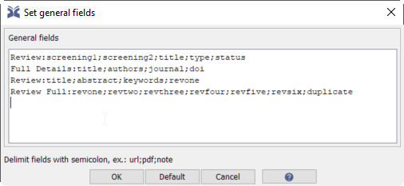

Figure 2: Screenshot of JabRef dialog used to set the general fields.

Add a dedicated field for the reviewing, showing only the title, abstract, and `screening1` fields. This allows you to focus on the relevant information while ignoring irrelevant and potentially biasing information (such as year, journal, and authors). Each row in this text area shows one tab. The first term on each row is the tab’s name, followed by a colon (`:`) and then the fields shown in the tab, separated by semicolons (`;`). For example, you could add the following row:

`Screening Round 1:title;abstract;screening1`

## Screening process

For every entry, add the following text in the ‘screening’ field:

- If it is excluded, add the reason, specifically (these are ordered progressively; i.e. if one of the criteria matches, apply it and move on to the next entry):
  - **`nohome`** if the study does not deal with the home advantage;
  - **`nosoccer`** if the study does not report on data exclusively for soccer (*also* reporting data for other sports is no grounds for exclusion of course)
  - **`nopro`** if the study does not report on data exclusively for professionals (*also* reporting data for amateur soccer is no grounds for exclusion of course)
- If it is included, add **`incl`**, followed by two opening brackets (**`[[`**) and a list of the relevant variables that were included separated by pipes (**`|`**) and terminated by two closing brackets (**`]]`**), such as `incl [[ supporting audience size | distance from home city ]]`

So once JabRef is opened, when screening, make sure that the ‘screening1’ field is shown in the entry table (i.e. that it is one of the entry table columns), and create one entry editing tab using ‘General Fields’ that contains the fields `title`, `abstract`, and `screening1`. You can then use this tab for the screening. It is also convenient to show field `dupl` in either the entry table or the screening tab in the entry editor, because for duplicate records (that were identified as such - the algorithm may miss some duplicates of course), that field contains the text `dupl`.

Make sure to save the database with query hits under a different name than “2018-05-14-screening.bib”. That is important because file “2018-05-14-screening.bib” will get overwritten if this R Markdown file is executed again.

## Second query, executed at: 2018-05-23

The query was updated to:

```
("Home advantage" OR "home court advantage" OR "home team advantage" OR "home venue advantage" OR "home field advantage" OR "game location") AND ("soccer" OR "football") NOT ("American Football" OR "Australian football")
```

This was run at 2018-05-23 in PubMed (61 hits) and PsycINFO accessed through EbscoHost (72 hits), and exported to the RIS format (called ‘medline’ in PubMed). The RIS files were then imported in R using `metabefor`.

```r
### Import PsycINFO hits
secondQueryIteration_psycinfo <-
  importRISlike(file.path(queryHitExportPath,
                          "psycinfo-2018-05-23.ris"),
                encoding="native.enc");
```

```
## Reading file 'B:/Data/research/home-advantage/queries/psycinfo-2018-05-23.ris'...
## Read 2961 lines.
## Extracted 72 lines matching regex '^TY' (regular RIS start of record).
##
## Extracting references...
##
##
## Interpreting references...
##
##
## Converting references to dataframe...
```

```r
### Import PubMed hits
secondQueryIteration_pubmed <-
  importRISlike(file.path(queryHitExportPath,
                          "pubmed-2018-05-23.ris"));
```

```
## Reading file 'B:/Data/research/home-advantage/queries/pubmed-2018-05-23.ris'...
## Read 3881 lines.
## Extracted 0 lines matching regex '^TY' (regular RIS start of record).
##
## Zero hits: looked for PubMed RIS export ('medline') markers:
## Extracted 61 lines matching regex '^PMID' (PubMed RIS start of record).
##
## Extracting references...
##
##
## Interpreting references...
##
##
## Converting references to dataframe...
```

```r
### Merge the two sets of hits
secondQueryIteration <-
  findDuplicateReferences(primaryRefs = secondQueryIteration_psycinfo,
                          secondaryRefs = secondQueryIteration_pubmed,
                          duplicateFieldValue = "dupl (2nd)",
                          newRecordValue = "PubMed (2nd)",
                          duplicateValue = "duplicate (both PsycINFO and PubMed; 2nd)",
                          originalValue = "PsycINFO (2nd)");
```

```
## Merging bibliographic databases and flagging duplicates. Processing 72 primary references and 61 secondary references. It is now 2018-07-20 15:50:45.
##
## Processed 72 primary and 61 secondary records. Identified 2 duplicate records. Total number of records in resulting set is 133, of which 2 duplicates. It is now 2018-07-20 15:50:46. The process took roughly: Time difference of 1.212758 secs.
```

```r
### Generate bibtex keys
secondQueryIteration$output$records <-
  generateBibtexkeys(secondQueryIteration$output$records);

### Add query date identifier to bibtex keys
secondQueryIteration$output$records$bibtexkey <-
  paste0(secondQueryIteration$output$records$bibtexkey,
         "-20180523");

### Import results from first query (these have been screened now)
firstQueryIteration_screened <-
  importBibtex(file.path(screeningPath,
                         "2018-05-14-screening#1.bib"));
```

```
##
## Converting references to dataframe...
```

```r
### Merge the screened reference database from the first query
### with the database from the second query
secondQueryIteration_merged <-
  findDuplicateReferences(primaryRefs = firstQueryIteration_screened,
                          secondaryRefs = secondQueryIteration,
                          duplicateFieldValue = "Screened in first iteration",
                          newRecordValue = "From second query",
                          duplicateValue = "From first query (screened in first iteration)",
                          originalValue = "screening1");
```

```
## Merging bibliographic databases and flagging duplicates. Processing 116 primary references and 133 secondary references. It is now 2018-07-20 15:50:47.
##
## Processed 116 primary and 133 secondary records. Identified 115 duplicate records. Total number of records in resulting set is 249, of which 115 duplicates. It is now 2018-07-20 15:50:52. The process took roughly: Time difference of 4.494564 secs.
```

```r
### The new records are stored in secondQueryIteration_merged$output$newRecords, so we
### can copy these to the database from the first screening. We also store the entire
### database so that we can document the process (and if need be, check whether anything
### went wrong).

secondScreening <- firstQueryIteration_screened;

secondScreening$output$records <- rbind.fill(secondScreening$output$records,
                                             secondQueryIteration_merged$output$newRecords);

### Export the hits to bibtex for screening in JabRef
sysrevExport(secondQueryIteration_merged,
             filename=file.path(screeningPath,
                                "2018-05-23-fully-merged-database.bib"),
             screeningType="screening");

sysrevExport(secondScreening,
             filename=file.path(screeningPath,
                                "2018-05-23-screening.bib"),
             screeningType="screening");
```

The merged bibliographic database has been stored in the screening path (B:/Data/research/home-advantage/screening), to file `2018-05-23-screening.bib`. This file can now be opened in JabRef, and should be saved to a different filename before any edits are made (because, after all, the file named `2018-05-23-screening.bib` will be overwritten every time this script runs).

In this merged database, field ‘screening1’ has been preserved. Records where this field is empty, therefore, are from the second query, and should be screened in the second screening sweep.

## Generation of the Extraction Script

We will use a metabefor extraction script for the extraction of the data. The idea of this script is to extract the data from the original sources with a minimum of interpretation. The data is extracted into a machine-readable format, which then allows competely transparent further processing and synthesis.

These scripts are generated on the basis of two tables/spreadsheets. The first contains the entities to extract, such as study year, sample size, how variables were operationalised, and associations that were found. The second contains the valid values for each entity, to allow efficiently providing coders with examples, instructions, and to allow easy verification of the input.

The completed extraction scripts are then read into R.

# Extraction script output

## 1, Fothergill2014.rxs.Rmd

Tree of extracted entities

```
                             levelName
1  study
2   ¦--studyId
3   ¦--comments
4   ¦--year
5   ¦--country
6   ¦--methods
7   ¦   ¦--N
8   ¦   ¦--Ntype
9   ¦   ¦--Enter name here (mandatory)
10  ¦   ¦--methodType
11  ¦   °--operationalisations
12  ¦--results
13  ¦   ¦--gameLocation
14  ¦   ¦--gameLocation
15  ¦   ¦--gameFactors
16  ¦   ¦--gameFactors
17  ¦   ¦--gameFactors
18  ¦   ¦--gameFactors
19  ¦   ¦--gameFactors
20  ¦   ¦--physiologicalState
21  ¦   ¦--PsychologicalState
22  ¦   ¦--CriticalBehavioralState
23  ¦   ¦--CriticalBehavioralState
24  °--assoc.nMatches
```

Table with extracted entities and extracted values

| path | entity | nodeValue |
| --- | --- | --- |
| study | studyId | 10.1080/1612197X.2014.932826 |
| study | comments |  |
| study | year | 2014 |
| study | country | GB |
| study/methods | N | 9 |
| study/methods | Ntype | person |
| study/methods/Enter name here (mandatory) | subsample.name | Enter name here (mandatory) |
| study/methods/Enter name here (mandatory) | subsample.N | NA |
| study/methods/Enter name here (mandatory) | subsample.Ntype | NA |
| study/methods | methodType | qualitative |
| study/methods | operationalisations |  |
| study/results/gameLocation | uni.name | gameLocation |
| study/results/gameLocation | uni.varname | homeLocation |
| study/results/gameLocation | uni.qualitative | My experience tells me as well that sometimes players will give an extra 5–10% playing at home than not and so that enthuses on the amount of desire that will be created at home because they have th… |
| study/results/gameLocation | uni.name | gameLocation |
| study/results/gameLocation | uni.varname | awayLocation |
| study/results/gameLocation | uni.qualitative | When you play in some old stadium like X or X you know it’s not very nice … .unfortunately you have to play at home and away. For me I don’t like to play away, it would be perfect to play at home,… |
| study/results/gameFactors | uni.name | gameFactors |
| study/results/gameFactors | uni.varname | crowd |
| study/results/gameFactors | uni.qualitative | I think the crowds were fantastic really, and I think even when the players probably weren’t er … at their best I think the crowd lifted them to you know give that little bit more which I think all … |
| study/results/gameFactors | uni.name | gameFactors |
| study/results/gameFactors | uni.varname | familiarity |
| study/results/gameFactors | uni.qualitative | It’s a more familiar feeling, the people when you get there the parking in your own parking place all the way through to like I say familiarity of seeing people you’re comfortable with, and the fa… |
| study/results/gameFactors | uni.name | gameFactors |
| study/results/gameFactors | uni.varname | territoriality |
| study/results/gameFactors | uni.qualitative | It was more like home because I spent most of my time there … you know you’re there on a daily basis the fixtures and fittings becomes second nature. The changing rooms, the corridors, the going out… |
| study/results/gameFactors | uni.name | gameFactors |
| study/results/gameFactors | uni.varname | travel |
| study/results/gameFactors | uni.qualitative | If we’ve got to go away a longer distance we travel the day before, sleep in hotels and that’s a bit different, but you’re still quite well rested and things. I don’t really like travelling on… |
| study/results/gameFactors | uni.name | gameFactors |
| study/results/gameFactors | uni.varname | referee |
| study/results/gameFactors | uni.qualitative | think the home fans when they put pressure for 90 minutes on the referee … they can affect him … little decisions you know when like you have someone fall on the floor in the box and you have 50,000 f… |
| study/results/physiologicalState | uni.name | physiologicalState |
| study/results/physiologicalState | uni.varname | physiological |
| study/results/physiologicalState | uni.qualitative | Yeah I think you’re definitely aware of it when things go well because I think you … you know get that adrenalin surge because you are doing well and the crowd respond. |
| study/results/PsychologicalState | uni.name | PsychologicalState |
| study/results/PsychologicalState | uni.varname | anxiety |
| study/results/PsychologicalState | uni.qualitative | You get some teams that are more abusive, get more behind their team it sort of depends if you play at X if you come on as a sub and warm up on the side you just get loads of abuse you do have places … |
| study/results/CriticalBehavioralState | uni.name | CriticalBehavioralState |
| study/results/CriticalBehavioralState | uni.varname | experience |
| study/results/CriticalBehavioralState | uni.qualitative | I’ve got my kids, family, just go home and you can just walk through the door and forget. I think there are some players and I didn’t used to be able to forget when I was younger. Now, experience … |
| study/results/CriticalBehavioralState | uni.name | CriticalBehavioralState |
| study/results/CriticalBehavioralState | uni.varname | tactics |
| study/results/CriticalBehavioralState | uni.qualitative | I think sometimes you can see some big differences when the team plays at home to away … like I think you attack more when you play at home and defend more when you play away. |
| study | assoc.nMatches | NA |

### Validation results

- Validation run starting at 2018-07-20 15:53
- Failed validation for ‘subsample.N’
- Failed validation for ‘subsample.Ntype’
- Failed validation for ‘assoc.nMatches’
- Validation run ending at 2018-07-20 15:54 function (e) { cat0(“error: ”) print(e) invisible(e) } <environment: 0x000000002614ea78>

## 115, Nevill1996.rxs.Rmd

Tree of extracted entities

```
                                      levelName
1  study
2   ¦--studyId
3   ¦--comments
4   ¦--year
5   ¦--country
6   ¦--methods
7   ¦   ¦--N
8   ¦   ¦--Ntype
9   ¦   ¦--Enter name here (mandatory)
10  ¦   ¦--methodType
11  ¦   °--operationalisations
12  ¦       ¦--homeTeamWinPrc
13  ¦       ¦--homeTeamRedCard
14  ¦       °--homePenaltyScored
15  ¦--results
16  ¦   ¦--homeTeamWinPrc_homeTeamRedCard
17  ¦   ¦--homeTeamWinPrc_homeTeamPenaltyScored
18  ¦   °--Enter name here (mandatory)
19  °--assoc.nMatches
```

Table with extracted entities and extracted values

| path | entity | nodeValue |
| --- | --- | --- |
| study | studyId | 10.1080/02640419608727700 |
| study | comments |  |
| study | year | 1992 |
| study | year | 1993 |
| study | country | GB |
| study/methods | N | 3291 |
| study/methods | Ntype | match |
| study/methods/Enter name here (mandatory) | subsample.name | Enter name here (mandatory) |
| study/methods/Enter name here (mandatory) | subsample.N | NA |
| study/methods/Enter name here (mandatory) | subsample.Ntype | NA |
| study/methods | methodType | quantitative |
| study/methods/operationalisations/homeTeamWinPrc | oper.name | homeTeamWinPrc |
| study/methods/operationalisations/homeTeamWinPrc | oper.moment | 1 |
| study/methods/operationalisations/homeTeamWinPrc | oper.type | NA |
| study/methods/operationalisations/homeTeamWinPrc | oper.datatype | numeric |
| study/methods/operationalisations/homeTeamWinPrc | oper.values | NA |
| study/methods/operationalisations/homeTeamWinPrc | oper.labels | NA |
| study/methods/operationalisations/homeTeamWinPrc | oper.description |  |
| study/methods/operationalisations/homeTeamWinPrc | oper.comment |  |
| study/methods/operationalisations/homeTeamRedCard | oper.name | homeTeamRedCard |
| study/methods/operationalisations/homeTeamRedCard | oper.moment | 1 |
| study/methods/operationalisations/homeTeamRedCard | oper.type | NA |
| study/methods/operationalisations/homeTeamRedCard | oper.datatype | numeric |
| study/methods/operationalisations/homeTeamRedCard | oper.values | NA |
| study/methods/operationalisations/homeTeamRedCard | oper.labels | NA |
| study/methods/operationalisations/homeTeamRedCard | oper.description |  |
| study/methods/operationalisations/homeTeamRedCard | oper.comment |  |
| study/methods/operationalisations/homePenaltyScored | oper.name | homePenaltyScored |
| study/methods/operationalisations/homePenaltyScored | oper.moment | 1 |
| study/methods/operationalisations/homePenaltyScored | oper.type | NA |

[output cut: 55 more lines]

### Validation results

- Validation run starting at 2018-07-20 15:55
- Failed validation for ‘subsample.N’
- Failed validation for ‘subsample.Ntype’
- Failed validation for ‘oper.type’
- Failed validation for ‘oper.values’
- Failed validation for ‘oper.labels’
- Failed validation for ‘oper.type’
- Failed validation for ‘oper.values’
- Failed validation for ‘oper.labels’
- Failed validation for ‘oper.type’
- Failed validation for ‘oper.values’
- Failed validation for ‘oper.labels’
- Failed validation for ‘assoc.n’
- Failed validation for ‘assoc.df’
- Failed validation for ‘assoc.t’
- Failed validation for ‘assoc.F’
- Failed validation for ‘assoc.z’
- Failed validation for ‘assoc.chisq’
- Failed validation for ‘assoc.d’
- Failed validation for ‘assoc.etasq’
- Failed validation for ‘assoc.omegasq’
- Failed validation for ‘assoc.OR’
- Failed validation for ‘assoc.p’
- Failed validation for ‘assoc.covariates’
- Failed validation for ‘assoc.comment’
- Failed validation for ‘assoc.n’
- Failed validation for ‘assoc.df’
- Failed validation for ‘assoc.t’
- Failed validation for ‘assoc.F’
- Failed validation for ‘assoc.z’
- Failed validation for ‘assoc.chisq’
- Failed validation for ‘assoc.d’
- Failed validation for ‘assoc.etasq’
- Failed validation for ‘assoc.omegasq’
- Failed validation for ‘assoc.OR’
- Failed validation for ‘assoc.p’
- Failed validation for ‘assoc.covariates’
- Failed validation for ‘assoc.comment’
- Failed validation for ‘uni.qualitative’
- Failed validation for ‘assoc.nMatches’
- Validation run ending at 2018-07-20 15:56 function (e) { cat0(“error: ”) print(e) invisible(e) } <environment: 0x000000002614ea78>

## 14, Thomas2006.rxs.Rmd

Tree of extracted entities

```
                                       levelName
1  study
2   ¦--studyId
3   ¦--comments
4   ¦--year
5   ¦--country
6   ¦--methods
7   ¦   ¦--N
8   ¦   ¦--Ntype
9   ¦   ¦--Enter name here (mandatory)
10  ¦   ¦--methodType
11  ¦   °--operationalisations
12  ¦       ¦--gameLocationIsHome
13  ¦       ¦--yellowDecidedGames
14  ¦       °--yellowTiedGames
15  ¦--results
16  ¦   ¦--gameLocationIsHome_yellowDecidedGames
17  ¦   ¦--gameLocationIsHome_yellowTiedGames
18  ¦   °--Enter name here (mandatory)
19  °--assoc.nMatches
```

Table with extracted entities and extracted values

| path | entity | nodeValue |
| --- | --- | --- |
| study | studyId | 10.2466/PMS.102.2.317-320 |
| study | comments |  |
| study | year | 2000 |
| study | year | 2001 |
| study | year | 2002 |
| study | year | 2003 |
| study | country | GB |
| study/methods | N | 1140 |
| study/methods | Ntype | match |
| study/methods/Enter name here (mandatory) | subsample.name | Enter name here (mandatory) |
| study/methods/Enter name here (mandatory) | subsample.N | NA |
| study/methods/Enter name here (mandatory) | subsample.Ntype | NA |
| study/methods | methodType | quantitative |
| study/methods/operationalisations/gameLocationIsHome | oper.name | gameLocationIsHome |
| study/methods/operationalisations/gameLocationIsHome | oper.moment | 1 |
| study/methods/operationalisations/gameLocationIsHome | oper.type | NA |
| study/methods/operationalisations/gameLocationIsHome | oper.datatype | logical |
| study/methods/operationalisations/gameLocationIsHome | oper.values | NA |
| study/methods/operationalisations/gameLocationIsHome | oper.labels | NA |
| study/methods/operationalisations/gameLocationIsHome | oper.description |  |
| study/methods/operationalisations/gameLocationIsHome | oper.comment |  |
| study/methods/operationalisations/yellowDecidedGames | oper.name | yellowDecidedGames |
| study/methods/operationalisations/yellowDecidedGames | oper.moment | 1 |
| study/methods/operationalisations/yellowDecidedGames | oper.type | NA |
| study/methods/operationalisations/yellowDecidedGames | oper.datatype | numeric |
| study/methods/operationalisations/yellowDecidedGames | oper.values | NA |
| study/methods/operationalisations/yellowDecidedGames | oper.labels | NA |
| study/methods/operationalisations/yellowDecidedGames | oper.description |  |
| study/methods/operationalisations/yellowDecidedGames | oper.comment |  |
| study/methods/operationalisations/yellowTiedGames | oper.name | yellowTiedGames |

[output cut: 57 more lines]

### Validation results

- Validation run starting at 2018-07-20 15:56
- Failed validation for ‘subsample.N’
- Failed validation for ‘subsample.Ntype’
- Failed validation for ‘oper.type’
- Failed validation for ‘oper.values’
- Failed validation for ‘oper.labels’
- Failed validation for ‘oper.type’
- Failed validation for ‘oper.values’
- Failed validation for ‘oper.labels’
- Failed validation for ‘oper.type’
- Failed validation for ‘oper.values’
- Failed validation for ‘oper.labels’
- Failed validation for ‘assoc.n’
- Failed validation for ‘assoc.df’
- Failed validation for ‘assoc.t’
- Failed validation for ‘assoc.F’
- Failed validation for ‘assoc.r’
- Failed validation for ‘assoc.z’
- Failed validation for ‘assoc.d’
- Failed validation for ‘assoc.etasq’
- Failed validation for ‘assoc.omegasq’
- Failed validation for ‘assoc.OR’
- Failed validation for ‘assoc.p’
- Failed validation for ‘assoc.covariates’
- Failed validation for ‘assoc.comment’
- Failed validation for ‘assoc.n’
- Failed validation for ‘assoc.df’
- Failed validation for ‘assoc.t’
- Failed validation for ‘assoc.F’
- Failed validation for ‘assoc.r’
- Failed validation for ‘assoc.z’
- Failed validation for ‘assoc.d’
- Failed validation for ‘assoc.etasq’
- Failed validation for ‘assoc.omegasq’
- Failed validation for ‘assoc.OR’
- Failed validation for ‘assoc.p’
- Failed validation for ‘assoc.covariates’
- Failed validation for ‘assoc.comment’
- Failed validation for ‘uni.qualitative’
- Failed validation for ‘assoc.nMatches’
- Validation run ending at 2018-07-20 15:57 function (e) { cat0(“error: ”) print(e) invisible(e) } <environment: 0x000000002614ea78>

## 23, Armatas2014.rxs.Rmd

Tree of extracted entities

```
                                              levelName
1  study
2   ¦--studyId
3   ¦--comments
4   ¦--year
5   ¦--country
6   ¦--methods
7   ¦   ¦--N
8   ¦   ¦--Ntype
9   ¦   ¦--season
10  ¦   ¦--methodType
11  ¦   °--operationalisations
12  ¦       ¦--gameLocationIsHome
13  ¦       ¦--cardsToFoulRatio
14  ¦       ¦--totalShots
```

[output cut: 37 more lines]

Table with extracted entities and extracted values

| path | entity | nodeValue |
| --- | --- | --- |
| study | studyId | 10.1080/17461391.2012.736537 |
| study | comments |  |
| study | year | NA |
| study | country | NA |
| study/methods | N | NA |
| study/methods | Ntype | NA |
| study/methods/season | subsample.name | season |
| study/methods/season | subsample.N | 17 |
| study/methods/season | subsample.Ntype | season |
| study/methods | methodType | quantitative |
| study/methods/operationalisations/gameLocationIsHome | oper.name | gameLocationIsHome |
| study/methods/operationalisations/gameLocationIsHome | oper.moment | 1 |
| study/methods/operationalisations/gameLocationIsHome | oper.type | NA |
| study/methods/operationalisations/gameLocationIsHome | oper.datatype | logical |
| study/methods/operationalisations/gameLocationIsHome | oper.values | NA |
| study/methods/operationalisations/gameLocationIsHome | oper.labels | NA |
| study/methods/operationalisations/gameLocationIsHome | oper.description |  |
| study/methods/operationalisations/gameLocationIsHome | oper.comment |  |
| study/methods/operationalisations/cardsToFoulRatio | oper.name | cardsToFoulRatio |
| study/methods/operationalisations/cardsToFoulRatio | oper.moment | 1 |
| study/methods/operationalisations/cardsToFoulRatio | oper.type | NA |
| study/methods/operationalisations/cardsToFoulRatio | oper.datatype | numeric |
| study/methods/operationalisations/cardsToFoulRatio | oper.values | NA |
| study/methods/operationalisations/cardsToFoulRatio | oper.labels | NA |
| study/methods/operationalisations/cardsToFoulRatio | oper.description |  |
| study/methods/operationalisations/cardsToFoulRatio | oper.comment |  |
| study/methods/operationalisations/totalShots | oper.name | totalShots |
| study/methods/operationalisations/totalShots | oper.moment | 1 |
| study/methods/operationalisations/totalShots | oper.type | NA |
| study/methods/operationalisations/totalShots | oper.datatype | numeric |

[output cut: 565 more lines]

### Validation results

- Validation run starting at 2018-07-20 15:59
- Failed validation for ‘year’
- Failed validation for ‘country’
- Failed validation for ‘N’
- Failed validation for ‘Ntype’
- Failed validation for ‘oper.type’
- Failed validation for ‘oper.values’
- Failed validation for ‘oper.labels’
- Failed validation for ‘oper.type’
- Failed validation for ‘oper.values’
- Failed validation for ‘oper.labels’
- Failed validation for ‘oper.type’
- Failed validation for ‘oper.values’
- Failed validation for ‘oper.labels’
- Failed validation for ‘oper.type’
- Failed validation for ‘oper.values’
- Failed validation for ‘oper.labels’
- Failed validation for ‘oper.type’
- Failed validation for ‘oper.values’
- Failed validation for ‘oper.labels’
- Failed validation for ‘oper.type’
- Failed validation for ‘oper.values’
- Failed validation for ‘oper.labels’
- Failed validation for ‘oper.type’
- Failed validation for ‘oper.values’
- Failed validation for ‘oper.labels’
- Failed validation for ‘oper.type’
- Failed validation for ‘oper.values’
- Failed validation for ‘oper.labels’
- Failed validation for ‘oper.type’
- Failed validation for ‘oper.values’
- Failed validation for ‘oper.labels’
- Failed validation for ‘oper.type’
- Failed validation for ‘oper.values’
- Failed validation for ‘oper.labels’
- Failed validation for ‘oper.type’
- Failed validation for ‘oper.values’
- Failed validation for ‘oper.labels’
- Failed validation for ‘oper.type’
- Failed validation for ‘oper.values’
- Failed validation for ‘oper.labels’
- Failed validation for ‘oper.type’
- Failed validation for ‘oper.values’
- Failed validation for ‘oper.labels’
- Failed validation for ‘oper.type’
- Failed validation for ‘oper.values’
- Failed validation for ‘oper.labels’
- Failed validation for ‘oper.type’
- Failed validation for ‘oper.values’
- Failed validation for ‘oper.labels’
- Failed validation for ‘oper.type’
- Failed validation for ‘oper.values’
- Failed validation for ‘oper.labels’
- Failed validation for ‘oper.type’
- Failed validation for ‘oper.values’
- Failed validation for ‘oper.labels’
- Failed validation for ‘oper.type’
- Failed validation for ‘oper.values’
- Failed validation for ‘oper.labels’
- Failed validation for ‘assoc.n’
- Failed validation for ‘assoc.df’
- Failed validation for ‘assoc.t’
- Failed validation for ‘assoc.F’
- Failed validation for ‘assoc.r’
- Failed validation for ‘assoc.z’
- Failed validation for ‘assoc.chisq’
- Failed validation for ‘assoc.etasq’
- Failed validation for ‘assoc.omegasq’
- Failed validation for ‘assoc.OR’
- Failed validation for ‘assoc.p’
- Failed validation for ‘assoc.covariates’
- Failed validation for ‘assoc.comment’
- Failed validation for ‘assoc.n’
- Failed validation for ‘assoc.df’
- Failed validation for ‘assoc.t’
- Failed validation for ‘assoc.F’
- Failed validation for ‘assoc.r’
- Failed validation for ‘assoc.z’
- Failed validation for ‘assoc.chisq’
- Failed validation for ‘assoc.etasq’
- Failed validation for ‘assoc.omegasq’
- Failed validation for ‘assoc.OR’
- Failed validation for ‘assoc.p’
- Failed validation for ‘assoc.covariates’
- Failed validation for ‘assoc.comment’
- Failed validation for ‘assoc.n’
- Failed validation for ‘assoc.df’
- Failed validation for ‘assoc.t’
- Failed validation for ‘assoc.F’
- Failed validation for ‘assoc.r’
- Failed validation for ‘assoc.z’
- Failed validation for ‘assoc.chisq’
- Failed validation for ‘assoc.etasq’
- Failed validation for ‘assoc.omegasq’
- Failed validation for ‘assoc.OR’
- Failed validation for ‘assoc.p’
- Failed validation for ‘assoc.covariates’
- Failed validation for ‘assoc.comment’
- Failed validation for ‘assoc.n’
- Failed validation for ‘assoc.df’
- Failed validation for ‘assoc.t’
- Failed validation for ‘assoc.F’
- Failed validation for ‘assoc.r’
- Failed validation for ‘assoc.z’
- Failed validation for ‘assoc.chisq’
- Failed validation for ‘assoc.etasq’
- Failed validation for ‘assoc.omegasq’
- Failed validation for ‘assoc.OR’
- Failed validation for ‘assoc.p’
- Failed validation for ‘assoc.covariates’
- Failed validation for ‘assoc.comment’
- Failed validation for ‘assoc.n’
- Failed validation for ‘assoc.df’
- Failed validation for ‘assoc.t’
- Failed validation for ‘assoc.F’
- Failed validation for ‘assoc.r’
- Failed validation for ‘assoc.z’
- Failed validation for ‘assoc.chisq’
- Failed validation for ‘assoc.etasq’
- Failed validation for ‘assoc.omegasq’
- Failed validation for ‘assoc.OR’
- Failed validation for ‘assoc.p’
- Failed validation for ‘assoc.covariates’
- Failed validation for ‘assoc.comment’
- Failed validation for ‘assoc.n’
- Failed validation for ‘assoc.df’
- Failed validation for ‘assoc.t’
- Failed validation for ‘assoc.F’
- Failed validation for ‘assoc.r’
- Failed validation for ‘assoc.z’
- Failed validation for ‘assoc.chisq’
- Failed validation for ‘assoc.etasq’
- Failed validation for ‘assoc.omegasq’
- Failed validation for ‘assoc.OR’
- Failed validation for ‘assoc.p’
- Failed validation for ‘assoc.covariates’
- Failed validation for ‘assoc.comment’
- Failed validation for ‘assoc.n’
- Failed validation for ‘assoc.df’
- Failed validation for ‘assoc.t’
- Failed validation for ‘assoc.F’
- Failed validation for ‘assoc.r’
- Failed validation for ‘assoc.z’
- Failed validation for ‘assoc.chisq’
- Failed validation for ‘assoc.etasq’
- Failed validation for ‘assoc.omegasq’
- Failed validation for ‘assoc.OR’
- Failed validation for ‘assoc.p’
- Failed validation for ‘assoc.covariates’
- Failed validation for ‘assoc.comment’
- Failed validation for ‘assoc.n’
- Failed validation for ‘assoc.df’
- Failed validation for ‘assoc.t’
- Failed validation for ‘assoc.F’
- Failed validation for ‘assoc.r’
- Failed validation for ‘assoc.z’
- Failed validation for ‘assoc.chisq’
- Failed validation for ‘assoc.etasq’
- Failed validation for ‘assoc.omegasq’
- Failed validation for ‘assoc.OR’
- Failed validation for ‘assoc.p’
- Failed validation for ‘assoc.covariates’
- Failed validation for ‘assoc.comment’
- Failed validation for ‘assoc.n’
- Failed validation for ‘assoc.df’
- Failed validation for ‘assoc.t’
- Failed validation for ‘assoc.F’
- Failed validation for ‘assoc.r’
- Failed validation for ‘assoc.z’
- Failed validation for ‘assoc.chisq’
- Failed validation for ‘assoc.etasq’
- Failed validation for ‘assoc.omegasq’
- Failed validation for ‘assoc.OR’
- Failed validation for ‘assoc.p’
- Failed validation for ‘assoc.covariates’
- Failed validation for ‘assoc.comment’
- Failed validation for ‘assoc.n’
- Failed validation for ‘assoc.df’
- Failed validation for ‘assoc.t’
- Failed validation for ‘assoc.F’
- Failed validation for ‘assoc.r’
- Failed validation for ‘assoc.z’
- Failed validation for ‘assoc.chisq’
- Failed validation for ‘assoc.etasq’
- Failed validation for ‘assoc.omegasq’
- Failed validation for ‘assoc.OR’
- Failed validation for ‘assoc.p’
- Failed validation for ‘assoc.covariates’
- Failed validation for ‘assoc.comment’
- Failed validation for ‘assoc.n’
- Failed validation for ‘assoc.df’
- Failed validation for ‘assoc.t’
- Failed validation for ‘assoc.F’
- Failed validation for ‘assoc.r’
- Failed validation for ‘assoc.z’
- Failed validation for ‘assoc.chisq’
- Failed validation for ‘assoc.etasq’
- Failed validation for ‘assoc.omegasq’
- Failed validation for ‘assoc.OR’
- Failed validation for ‘assoc.p’
- Failed validation for ‘assoc.covariates’
- Failed validation for ‘assoc.comment’
- Failed validation for ‘assoc.n’
- Failed validation for ‘assoc.df’
- Failed validation for ‘assoc.t’
- Failed validation for ‘assoc.F’
- Failed validation for ‘assoc.r’
- Failed validation for ‘assoc.z’
- Failed validation for ‘assoc.chisq’
- Failed validation for ‘assoc.etasq’
- Failed validation for ‘assoc.omegasq’
- Failed validation for ‘assoc.OR’
- Failed validation for ‘assoc.p’
- Failed validation for ‘assoc.covariates’
- Failed validation for ‘assoc.comment’
- Failed validation for ‘assoc.n’
- Failed validation for ‘assoc.df’
- Failed validation for ‘assoc.t’
- Failed validation for ‘assoc.F’
- Failed validation for ‘assoc.r’
- Failed validation for ‘assoc.z’
- Failed validation for ‘assoc.chisq’
- Failed validation for ‘assoc.etasq’
- Failed validation for ‘assoc.omegasq’
- Failed validation for ‘assoc.OR’
- Failed validation for ‘assoc.p’
- Failed validation for ‘assoc.covariates’
- Failed validation for ‘assoc.comment’
- Failed validation for ‘assoc.n’
- Failed validation for ‘assoc.df’
- Failed validation for ‘assoc.t’
- Failed validation for ‘assoc.F’
- Failed validation for ‘assoc.r’
- Failed validation for ‘assoc.z’
- Failed validation for ‘assoc.chisq’
- Failed validation for ‘assoc.etasq’
- Failed validation for ‘assoc.omegasq’
- Failed validation for ‘assoc.OR’
- Failed validation for ‘assoc.p’
- Failed validation for ‘assoc.covariates’
- Failed validation for ‘assoc.comment’
- Failed validation for ‘assoc.n’
- Failed validation for ‘assoc.df’
- Failed validation for ‘assoc.t’
- Failed validation for ‘assoc.F’
- Failed validation for ‘assoc.z’
- Failed validation for ‘assoc.chisq’
- Failed validation for ‘assoc.d’
- Failed validation for ‘assoc.etasq’
- Failed validation for ‘assoc.omegasq’
- Failed validation for ‘assoc.OR’
- Failed validation for ‘assoc.p’
- Failed validation for ‘assoc.covariates’
- Failed validation for ‘assoc.comment’
- Failed validation for ‘assoc.n’
- Failed validation for ‘assoc.df’
- Failed validation for ‘assoc.t’
- Failed validation for ‘assoc.F’
- Failed validation for ‘assoc.z’
- Failed validation for ‘assoc.chisq’
- Failed validation for ‘assoc.d’
- Failed validation for ‘assoc.etasq’
- Failed validation for ‘assoc.omegasq’
- Failed validation for ‘assoc.OR’
- Failed validation for ‘assoc.p’
- Failed validation for ‘assoc.covariates’
- Failed validation for ‘assoc.comment’
- Failed validation for ‘assoc.n’
- Failed validation for ‘assoc.df’
- Failed validation for ‘assoc.t’
- Failed validation for ‘assoc.F’
- Failed validation for ‘assoc.z’
- Failed validation for ‘assoc.chisq’
- Failed validation for ‘assoc.d’
- Failed validation for ‘assoc.etasq’
- Failed validation for ‘assoc.omegasq’
- Failed validation for ‘assoc.OR’
- Failed validation for ‘assoc.p’
- Failed validation for ‘assoc.covariates’
- Failed validation for ‘assoc.comment’
- Failed validation for ‘assoc.n’
- Failed validation for ‘assoc.df’
- Failed validation for ‘assoc.t’
- Failed validation for ‘assoc.F’
- Failed validation for ‘assoc.z’
- Failed validation for ‘assoc.chisq’
- Failed validation for ‘assoc.d’
- Failed validation for ‘assoc.etasq’
- Failed validation for ‘assoc.omegasq’
- Failed validation for ‘assoc.OR’
- Failed validation for ‘assoc.p’
- Failed validation for ‘assoc.covariates’
- Failed validation for ‘assoc.comment’
- Failed validation for ‘assoc.n’
- Failed validation for ‘assoc.df’
- Failed validation for ‘assoc.t’
- Failed validation for ‘assoc.F’
- Failed validation for ‘assoc.r’
- Failed validation for ‘assoc.z’
- Failed validation for ‘assoc.chisq’
- Failed validation for ‘assoc.etasq’
- Failed validation for ‘assoc.omegasq’
- Failed validation for ‘assoc.OR’
- Failed validation for ‘assoc.p’
- Failed validation for ‘assoc.covariates’
- Failed validation for ‘assoc.comment’
- Failed validation for ‘uni.qualitative’
- Failed validation for ‘assoc.nMatches’
- Validation run ending at 2018-07-20 15:00 function (e) { cat0(“error: ”) print(e) invisible(e) } <environment: 0x000000002614ea78>

## 25, Staufebiel2015.rxs.Rmd

Tree of extracted entities

```
                                             levelName
1  study
2   ¦--studyId
3   ¦--comments
4   ¦--year
5   ¦--country
6   ¦--methods
7   ¦   ¦--N
8   ¦   ¦--Ntype
9   ¦   ¦--Enter name here (mandatory)
10  ¦   ¦--methodType
11  ¦   °--operationalisations
12  ¦       ¦--gameLocationIsHome
13  ¦       ¦--internalEfficacy
14  ¦       ¦--externalEfficacy
```

[output cut: 17 more lines]

Table with extracted entities and extracted values

| path | entity | nodeValue |
| --- | --- | --- |
| study | studyId | 10.1080/02640414.2015.1018929 |
| study | comments |  |
| study | year | 2013 |
| study | year | 2014 |
| study | country | DE |
| study/methods | N | 297 |
| study/methods | Ntype | person |
| study/methods/Enter name here (mandatory) | subsample.name | Enter name here (mandatory) |
| study/methods/Enter name here (mandatory) | subsample.N | NA |
| study/methods/Enter name here (mandatory) | subsample.Ntype | NA |
| study/methods | methodType | quantitative |
| study/methods/operationalisations/gameLocationIsHome | oper.name | gameLocationIsHome |
| study/methods/operationalisations/gameLocationIsHome | oper.moment | 1 |
| study/methods/operationalisations/gameLocationIsHome | oper.type | NA |
| study/methods/operationalisations/gameLocationIsHome | oper.datatype | logical |
| study/methods/operationalisations/gameLocationIsHome | oper.values | NA |
| study/methods/operationalisations/gameLocationIsHome | oper.labels | NA |
| study/methods/operationalisations/gameLocationIsHome | oper.description |  |
| study/methods/operationalisations/gameLocationIsHome | oper.comment |  |
| study/methods/operationalisations/internalEfficacy | oper.name | internalEfficacy |
| study/methods/operationalisations/internalEfficacy | oper.moment | 1 |
| study/methods/operationalisations/internalEfficacy | oper.type | NA |
| study/methods/operationalisations/internalEfficacy | oper.datatype | numeric |
| study/methods/operationalisations/internalEfficacy | oper.values | NA |
| study/methods/operationalisations/internalEfficacy | oper.labels | NA |
| study/methods/operationalisations/internalEfficacy | oper.description |  |
| study/methods/operationalisations/internalEfficacy | oper.comment |  |
| study/methods/operationalisations/externalEfficacy | oper.name | externalEfficacy |
| study/methods/operationalisations/externalEfficacy | oper.moment | 1 |
| study/methods/operationalisations/externalEfficacy | oper.type | NA |

[output cut: 226 more lines]

### Validation results

- Validation run starting at 2018-07-20 15:01
- Failed validation for ‘subsample.N’
- Failed validation for ‘subsample.Ntype’
- Failed validation for ‘oper.type’
- Failed validation for ‘oper.values’
- Failed validation for ‘oper.labels’
- Failed validation for ‘oper.type’
- Failed validation for ‘oper.values’
- Failed validation for ‘oper.labels’
- Failed validation for ‘oper.type’
- Failed validation for ‘oper.values’
- Failed validation for ‘oper.labels’
- Failed validation for ‘oper.type’
- Failed validation for ‘oper.values’
- Failed validation for ‘oper.labels’
- Failed validation for ‘oper.type’
- Failed validation for ‘oper.values’
- Failed validation for ‘oper.labels’
- Failed validation for ‘oper.type’
- Failed validation for ‘oper.values’
- Failed validation for ‘oper.labels’
- Failed validation for ‘oper.type’
- Failed validation for ‘oper.values’
- Failed validation for ‘oper.labels’
- Failed validation for ‘oper.type’
- Failed validation for ‘oper.values’
- Failed validation for ‘oper.labels’
- Failed validation for ‘oper.type’
- Failed validation for ‘oper.values’
- Failed validation for ‘oper.labels’
- Failed validation for ‘oper.type’
- Failed validation for ‘oper.values’
- Failed validation for ‘oper.labels’
- Failed validation for ‘assoc.n’
- Failed validation for ‘assoc.df’
- Failed validation for ‘assoc.t’
- Failed validation for ‘assoc.F’
- Failed validation for ‘assoc.r’
- Failed validation for ‘assoc.z’
- Failed validation for ‘assoc.chisq’
- Failed validation for ‘assoc.d’
- Failed validation for ‘assoc.omegasq’
- Failed validation for ‘assoc.OR’
- Failed validation for ‘assoc.p’
- Failed validation for ‘assoc.covariates’
- Failed validation for ‘assoc.comment’
- Failed validation for ‘assoc.n’
- Failed validation for ‘assoc.df’
- Failed validation for ‘assoc.t’
- Failed validation for ‘assoc.F’
- Failed validation for ‘assoc.r’
- Failed validation for ‘assoc.z’
- Failed validation for ‘assoc.chisq’
- Failed validation for ‘assoc.d’
- Failed validation for ‘assoc.omegasq’
- Failed validation for ‘assoc.OR’
- Failed validation for ‘assoc.p’
- Failed validation for ‘assoc.covariates’
- Failed validation for ‘assoc.comment’
- Failed validation for ‘assoc.n’
- Failed validation for ‘assoc.df’
- Failed validation for ‘assoc.t’
- Failed validation for ‘assoc.F’
- Failed validation for ‘assoc.r’
- Failed validation for ‘assoc.z’
- Failed validation for ‘assoc.chisq’
- Failed validation for ‘assoc.d’
- Failed validation for ‘assoc.omegasq’
- Failed validation for ‘assoc.OR’
- Failed validation for ‘assoc.p’
- Failed validation for ‘assoc.covariates’
- Failed validation for ‘assoc.comment’
- Failed validation for ‘assoc.n’
- Failed validation for ‘assoc.df’
- Failed validation for ‘assoc.t’
- Failed validation for ‘assoc.F’
- Failed validation for ‘assoc.r’
- Failed validation for ‘assoc.z’
- Failed validation for ‘assoc.chisq’
- Failed validation for ‘assoc.d’
- Failed validation for ‘assoc.omegasq’
- Failed validation for ‘assoc.OR’
- Failed validation for ‘assoc.p’
- Failed validation for ‘assoc.covariates’
- Failed validation for ‘assoc.comment’
- Failed validation for ‘assoc.n’
- Failed validation for ‘assoc.df’
- Failed validation for ‘assoc.t’
- Failed validation for ‘assoc.F’
- Failed validation for ‘assoc.r’
- Failed validation for ‘assoc.z’
- Failed validation for ‘assoc.chisq’
- Failed validation for ‘assoc.d’
- Failed validation for ‘assoc.omegasq’
- Failed validation for ‘assoc.OR’
- Failed validation for ‘assoc.p’
- Failed validation for ‘assoc.covariates’
- Failed validation for ‘assoc.comment’
- Failed validation for ‘assoc.n’
- Failed validation for ‘assoc.df’
- Failed validation for ‘assoc.t’
- Failed validation for ‘assoc.F’
- Failed validation for ‘assoc.z’
- Failed validation for ‘assoc.chisq’
- Failed validation for ‘assoc.d’
- Failed validation for ‘assoc.etasq’
- Failed validation for ‘assoc.omegasq’
- Failed validation for ‘assoc.OR’
- Failed validation for ‘assoc.p’
- Failed validation for ‘assoc.covariates’
- Failed validation for ‘assoc.comment’
- Failed validation for ‘assoc.n’
- Failed validation for ‘assoc.df’
- Failed validation for ‘assoc.t’
- Failed validation for ‘assoc.F’
- Failed validation for ‘assoc.z’
- Failed validation for ‘assoc.chisq’
- Failed validation for ‘assoc.d’
- Failed validation for ‘assoc.etasq’
- Failed validation for ‘assoc.omegasq’
- Failed validation for ‘assoc.OR’
- Failed validation for ‘assoc.p’
- Failed validation for ‘assoc.covariates’
- Failed validation for ‘assoc.comment’
- Failed validation for ‘uni.qualitative’
- Failed validation for ‘assoc.nMatches’
- Validation run ending at 2018-07-20 15:02 function (e) { cat0(“error: ”) print(e) invisible(e) } <environment: 0x000000002614ea78>

## 28, Seckin2008.rxs.Rmd

Tree of extracted entities

```
                                                 levelName
1  study
2   ¦--studyId
3   ¦--comments
4   ¦--year
5   ¦--country
6   ¦--methods
7   ¦   ¦--N
8   ¦   ¦--Ntype
9   ¦   ¦--season
10  ¦   ¦--methodType
11  ¦   °--operationalisations
12  ¦       ¦--gameLocationIsHome
13  ¦       ¦--shots
14  ¦       ¦--shotsResultInGoal
```

[output cut: 19 more lines]

Table with extracted entities and extracted values

| path | entity | nodeValue |
| --- | --- | --- |
| study | studyId | 10.2466/PMS.107.5.51-54 |
| study | comments |  |
| study | year | 1994 |
| study | year | 1995 |
| study | year | 1996 |
| study | year | 1997 |
| study | year | 1998 |
| study | year | 1999 |
| study | year | 2000 |
| study | year | 2001 |
| study | year | 2002 |
| study | year | 2003 |
| study | year | 2004 |
| study | year | 2005 |
| study | year | 2006 |
| study | country | TR |
| study/methods | N | NA |
| study/methods | Ntype | NA |
| study/methods/season | subsample.name | season |
| study/methods/season | subsample.N | 12 |
| study/methods/season | subsample.Ntype | season |
| study/methods | methodType | quantitative |
| study/methods/operationalisations/gameLocationIsHome | oper.name | gameLocationIsHome |
| study/methods/operationalisations/gameLocationIsHome | oper.moment | 1 |
| study/methods/operationalisations/gameLocationIsHome | oper.type | NA |
| study/methods/operationalisations/gameLocationIsHome | oper.datatype | logical |
| study/methods/operationalisations/gameLocationIsHome | oper.values | NA |
| study/methods/operationalisations/gameLocationIsHome | oper.labels | NA |
| study/methods/operationalisations/gameLocationIsHome | oper.description |  |
| study/methods/operationalisations/gameLocationIsHome | oper.comment |  |

[output cut: 283 more lines]

### Validation results

- Validation run starting at 2018-07-20 15:03
- Failed validation for ‘N’
- Failed validation for ‘Ntype’
- Failed validation for ‘oper.type’
- Failed validation for ‘oper.values’
- Failed validation for ‘oper.labels’
- Failed validation for ‘oper.type’
- Failed validation for ‘oper.values’
- Failed validation for ‘oper.labels’
- Failed validation for ‘oper.type’
- Failed validation for ‘oper.values’
- Failed validation for ‘oper.labels’
- Failed validation for ‘oper.type’
- Failed validation for ‘oper.values’
- Failed validation for ‘oper.labels’
- Failed validation for ‘oper.type’
- Failed validation for ‘oper.values’
- Failed validation for ‘oper.labels’
- Failed validation for ‘oper.type’
- Failed validation for ‘oper.values’
- Failed validation for ‘oper.labels’
- Failed validation for ‘oper.type’
- Failed validation for ‘oper.values’
- Failed validation for ‘oper.labels’
- Failed validation for ‘oper.type’
- Failed validation for ‘oper.values’
- Failed validation for ‘oper.labels’
- Failed validation for ‘oper.type’
- Failed validation for ‘oper.values’
- Failed validation for ‘oper.labels’
- Failed validation for ‘oper.type’
- Failed validation for ‘oper.values’
- Failed validation for ‘oper.labels’
- Failed validation for ‘assoc.n’
- Failed validation for ‘assoc.df’
- Failed validation for ‘assoc.t’
- Failed validation for ‘assoc.F’
- Failed validation for ‘assoc.r’
- Failed validation for ‘assoc.z’
- Failed validation for ‘assoc.chisq’
- Failed validation for ‘assoc.etasq’
- Failed validation for ‘assoc.omegasq’
- Failed validation for ‘assoc.OR’
- Failed validation for ‘assoc.p’
- Failed validation for ‘assoc.covariates’
- Failed validation for ‘assoc.comment’
- Failed validation for ‘assoc.n’
- Failed validation for ‘assoc.df’
- Failed validation for ‘assoc.t’
- Failed validation for ‘assoc.F’
- Failed validation for ‘assoc.r’
- Failed validation for ‘assoc.z’
- Failed validation for ‘assoc.chisq’
- Failed validation for ‘assoc.etasq’
- Failed validation for ‘assoc.omegasq’
- Failed validation for ‘assoc.OR’
- Failed validation for ‘assoc.p’
- Failed validation for ‘assoc.covariates’
- Failed validation for ‘assoc.comment’
- Failed validation for ‘assoc.n’
- Failed validation for ‘assoc.df’
- Failed validation for ‘assoc.t’
- Failed validation for ‘assoc.F’
- Failed validation for ‘assoc.r’
- Failed validation for ‘assoc.z’
- Failed validation for ‘assoc.chisq’
- Failed validation for ‘assoc.etasq’
- Failed validation for ‘assoc.omegasq’
- Failed validation for ‘assoc.OR’
- Failed validation for ‘assoc.p’
- Failed validation for ‘assoc.covariates’
- Failed validation for ‘assoc.comment’
- Failed validation for ‘assoc.n’
- Failed validation for ‘assoc.df’
- Failed validation for ‘assoc.t’
- Failed validation for ‘assoc.F’
- Failed validation for ‘assoc.r’
- Failed validation for ‘assoc.z’
- Failed validation for ‘assoc.chisq’
- Failed validation for ‘assoc.etasq’
- Failed validation for ‘assoc.omegasq’
- Failed validation for ‘assoc.OR’
- Failed validation for ‘assoc.p’
- Failed validation for ‘assoc.covariates’
- Failed validation for ‘assoc.comment’
- Failed validation for ‘assoc.n’
- Failed validation for ‘assoc.df’
- Failed validation for ‘assoc.t’
- Failed validation for ‘assoc.F’
- Failed validation for ‘assoc.r’
- Failed validation for ‘assoc.z’
- Failed validation for ‘assoc.chisq’
- Failed validation for ‘assoc.etasq’
- Failed validation for ‘assoc.omegasq’
- Failed validation for ‘assoc.OR’
- Failed validation for ‘assoc.p’
- Failed validation for ‘assoc.covariates’
- Failed validation for ‘assoc.comment’
- Failed validation for ‘assoc.n’
- Failed validation for ‘assoc.df’
- Failed validation for ‘assoc.t’
- Failed validation for ‘assoc.F’
- Failed validation for ‘assoc.r’
- Failed validation for ‘assoc.z’
- Failed validation for ‘assoc.chisq’
- Failed validation for ‘assoc.etasq’
- Failed validation for ‘assoc.omegasq’
- Failed validation for ‘assoc.OR’
- Failed validation for ‘assoc.p’
- Failed validation for ‘assoc.covariates’
- Failed validation for ‘assoc.comment’
- Failed validation for ‘assoc.n’
- Failed validation for ‘assoc.df’
- Failed validation for ‘assoc.t’
- Failed validation for ‘assoc.F’
- Failed validation for ‘assoc.r’
- Failed validation for ‘assoc.z’
- Failed validation for ‘assoc.chisq’
- Failed validation for ‘assoc.etasq’
- Failed validation for ‘assoc.omegasq’
- Failed validation for ‘assoc.OR’
- Failed validation for ‘assoc.p’
- Failed validation for ‘assoc.covariates’
- Failed validation for ‘assoc.comment’
- Failed validation for ‘assoc.n’
- Failed validation for ‘assoc.df’
- Failed validation for ‘assoc.t’
- Failed validation for ‘assoc.F’
- Failed validation for ‘assoc.r’
- Failed validation for ‘assoc.z’
- Failed validation for ‘assoc.chisq’
- Failed validation for ‘assoc.etasq’
- Failed validation for ‘assoc.omegasq’
- Failed validation for ‘assoc.OR’
- Failed validation for ‘assoc.p’
- Failed validation for ‘assoc.covariates’
- Failed validation for ‘assoc.comment’
- Failed validation for ‘assoc.n’
- Failed validation for ‘assoc.df’
- Failed validation for ‘assoc.t’
- Failed validation for ‘assoc.F’
- Failed validation for ‘assoc.r’
- Failed validation for ‘assoc.z’
- Failed validation for ‘assoc.chisq’
- Failed validation for ‘assoc.etasq’
- Failed validation for ‘assoc.omegasq’
- Failed validation for ‘assoc.OR’
- Failed validation for ‘assoc.p’
- Failed validation for ‘assoc.covariates’
- Failed validation for ‘assoc.comment’
- Failed validation for ‘uni.qualitative’
- Failed validation for ‘assoc.nMatches’
- Validation run ending at 2018-07-20 15:04 function (e) { cat0(“error: ”) print(e) invisible(e) } <environment: 0x000000002614ea78>

## 35, Gelade2015.rxs.Rmd

Tree of extracted entities

```
                                 levelName
1  study
2   ¦--studyId
3   ¦--comments
4   ¦--year
5   ¦--country
6   ¦--methods
7   ¦   ¦--N
8   ¦   ¦--Ntype
9   ¦   ¦--season
10  ¦   ¦--methodType
11  ¦   °--operationalisations
12  ¦       ¦--haPointsPrc
13  ¦       ¦--individualism
14  ¦       ¦--collectivism
```

[output cut: 23 more lines]

Table with extracted entities and extracted values

| path | entity | nodeValue |
| --- | --- | --- |
| study | studyId | 10.1177/1069397114556055 |
| study | comments |  |
| study | year | NA |
| study | country | global |
| study/methods | N | NA |
| study/methods | Ntype | NA |
| study/methods/season | subsample.name | season |
| study/methods/season | subsample.N | 6 |
| study/methods/season | subsample.Ntype | season |
| study/methods | methodType | quantitative |
| study/methods/operationalisations/haPointsPrc | oper.name | haPointsPrc |
| study/methods/operationalisations/haPointsPrc | oper.moment | 1 |
| study/methods/operationalisations/haPointsPrc | oper.type | NA |
| study/methods/operationalisations/haPointsPrc | oper.datatype | numeric |
| study/methods/operationalisations/haPointsPrc | oper.values | NA |
| study/methods/operationalisations/haPointsPrc | oper.labels | NA |
| study/methods/operationalisations/haPointsPrc | oper.description |  |
| study/methods/operationalisations/haPointsPrc | oper.comment |  |
| study/methods/operationalisations/individualism | oper.name | individualism |
| study/methods/operationalisations/individualism | oper.moment | 1 |
| study/methods/operationalisations/individualism | oper.type | NA |
| study/methods/operationalisations/individualism | oper.datatype | numeric |
| study/methods/operationalisations/individualism | oper.values | NA |
| study/methods/operationalisations/individualism | oper.labels | NA |
| study/methods/operationalisations/individualism | oper.description |  |
| study/methods/operationalisations/individualism | oper.comment |  |
| study/methods/operationalisations/collectivism | oper.name | collectivism |
| study/methods/operationalisations/collectivism | oper.moment | 1 |
| study/methods/operationalisations/collectivism | oper.type | NA |
| study/methods/operationalisations/collectivism | oper.datatype | numeric |

[output cut: 333 more lines]

### Validation results

- Validation run starting at 2018-07-20 15:05
- Failed validation for ‘year’
- Failed validation for ‘country’
- Failed validation for ‘N’
- Failed validation for ‘Ntype’
- Failed validation for ‘oper.type’
- Failed validation for ‘oper.values’
- Failed validation for ‘oper.labels’
- Failed validation for ‘oper.type’
- Failed validation for ‘oper.values’
- Failed validation for ‘oper.labels’
- Failed validation for ‘oper.type’
- Failed validation for ‘oper.values’
- Failed validation for ‘oper.labels’
- Failed validation for ‘oper.type’
- Failed validation for ‘oper.values’
- Failed validation for ‘oper.labels’
- Failed validation for ‘oper.type’
- Failed validation for ‘oper.values’
- Failed validation for ‘oper.labels’
- Failed validation for ‘oper.type’
- Failed validation for ‘oper.values’
- Failed validation for ‘oper.labels’
- Failed validation for ‘oper.type’
- Failed validation for ‘oper.values’
- Failed validation for ‘oper.labels’
- Failed validation for ‘oper.type’
- Failed validation for ‘oper.values’
- Failed validation for ‘oper.labels’
- Failed validation for ‘oper.type’
- Failed validation for ‘oper.values’
- Failed validation for ‘oper.labels’
- Failed validation for ‘oper.type’
- Failed validation for ‘oper.values’
- Failed validation for ‘oper.labels’
- Failed validation for ‘oper.type’
- Failed validation for ‘oper.values’
- Failed validation for ‘oper.labels’
- Failed validation for ‘oper.type’
- Failed validation for ‘oper.values’
- Failed validation for ‘oper.labels’
- Failed validation for ‘assoc.n’
- Failed validation for ‘assoc.df’
- Failed validation for ‘assoc.t’
- Failed validation for ‘assoc.F’
- Failed validation for ‘assoc.z’
- Failed validation for ‘assoc.chisq’
- Failed validation for ‘assoc.d’
- Failed validation for ‘assoc.etasq’
- Failed validation for ‘assoc.omegasq’
- Failed validation for ‘assoc.OR’
- Failed validation for ‘assoc.p’
- Failed validation for ‘assoc.covariates’
- Failed validation for ‘assoc.comment’
- Failed validation for ‘assoc.n’
- Failed validation for ‘assoc.df’
- Failed validation for ‘assoc.t’
- Failed validation for ‘assoc.F’
- Failed validation for ‘assoc.z’
- Failed validation for ‘assoc.chisq’
- Failed validation for ‘assoc.d’
- Failed validation for ‘assoc.etasq’
- Failed validation for ‘assoc.omegasq’
- Failed validation for ‘assoc.OR’
- Failed validation for ‘assoc.p’
- Failed validation for ‘assoc.covariates’
- Failed validation for ‘assoc.comment’
- Failed validation for ‘assoc.n’
- Failed validation for ‘assoc.df’
- Failed validation for ‘assoc.t’
- Failed validation for ‘assoc.F’
- Failed validation for ‘assoc.z’
- Failed validation for ‘assoc.chisq’
- Failed validation for ‘assoc.d’
- Failed validation for ‘assoc.etasq’
- Failed validation for ‘assoc.omegasq’
- Failed validation for ‘assoc.OR’
- Failed validation for ‘assoc.p’
- Failed validation for ‘assoc.covariates’
- Failed validation for ‘assoc.comment’
- Failed validation for ‘assoc.n’
- Failed validation for ‘assoc.df’
- Failed validation for ‘assoc.t’
- Failed validation for ‘assoc.F’
- Failed validation for ‘assoc.z’
- Failed validation for ‘assoc.chisq’
- Failed validation for ‘assoc.d’
- Failed validation for ‘assoc.etasq’
- Failed validation for ‘assoc.omegasq’
- Failed validation for ‘assoc.OR’
- Failed validation for ‘assoc.p’
- Failed validation for ‘assoc.covariates’
- Failed validation for ‘assoc.comment’
- Failed validation for ‘assoc.n’
- Failed validation for ‘assoc.df’
- Failed validation for ‘assoc.t’
- Failed validation for ‘assoc.F’
- Failed validation for ‘assoc.z’
- Failed validation for ‘assoc.chisq’
- Failed validation for ‘assoc.d’
- Failed validation for ‘assoc.etasq’
- Failed validation for ‘assoc.omegasq’
- Failed validation for ‘assoc.OR’
- Failed validation for ‘assoc.p’
- Failed validation for ‘assoc.covariates’
- Failed validation for ‘assoc.comment’
- Failed validation for ‘assoc.n’
- Failed validation for ‘assoc.df’
- Failed validation for ‘assoc.t’
- Failed validation for ‘assoc.F’
- Failed validation for ‘assoc.z’
- Failed validation for ‘assoc.chisq’
- Failed validation for ‘assoc.d’
- Failed validation for ‘assoc.etasq’
- Failed validation for ‘assoc.omegasq’
- Failed validation for ‘assoc.OR’
- Failed validation for ‘assoc.p’
- Failed validation for ‘assoc.covariates’
- Failed validation for ‘assoc.comment’
- Failed validation for ‘assoc.n’
- Failed validation for ‘assoc.df’
- Failed validation for ‘assoc.t’
- Failed validation for ‘assoc.F’
- Failed validation for ‘assoc.z’
- Failed validation for ‘assoc.chisq’
- Failed validation for ‘assoc.d’
- Failed validation for ‘assoc.etasq’
- Failed validation for ‘assoc.omegasq’
- Failed validation for ‘assoc.OR’
- Failed validation for ‘assoc.p’
- Failed validation for ‘assoc.covariates’
- Failed validation for ‘assoc.comment’
- Failed validation for ‘assoc.n’
- Failed validation for ‘assoc.df’
- Failed validation for ‘assoc.t’
- Failed validation for ‘assoc.F’
- Failed validation for ‘assoc.z’
- Failed validation for ‘assoc.chisq’
- Failed validation for ‘assoc.d’
- Failed validation for ‘assoc.etasq’
- Failed validation for ‘assoc.omegasq’
- Failed validation for ‘assoc.OR’
- Failed validation for ‘assoc.p’
- Failed validation for ‘assoc.covariates’
- Failed validation for ‘assoc.comment’
- Failed validation for ‘assoc.n’
- Failed validation for ‘assoc.df’
- Failed validation for ‘assoc.t’
- Failed validation for ‘assoc.F’
- Failed validation for ‘assoc.z’
- Failed validation for ‘assoc.chisq’
- Failed validation for ‘assoc.d’
- Failed validation for ‘assoc.etasq’
- Failed validation for ‘assoc.omegasq’
- Failed validation for ‘assoc.OR’
- Failed validation for ‘assoc.p’
- Failed validation for ‘assoc.covariates’
- Failed validation for ‘assoc.comment’
- Failed validation for ‘assoc.n’
- Failed validation for ‘assoc.df’
- Failed validation for ‘assoc.t’
- Failed validation for ‘assoc.F’
- Failed validation for ‘assoc.z’
- Failed validation for ‘assoc.chisq’
- Failed validation for ‘assoc.d’
- Failed validation for ‘assoc.etasq’
- Failed validation for ‘assoc.omegasq’
- Failed validation for ‘assoc.OR’
- Failed validation for ‘assoc.p’
- Failed validation for ‘assoc.covariates’
- Failed validation for ‘assoc.comment’
- Failed validation for ‘assoc.n’
- Failed validation for ‘assoc.df’
- Failed validation for ‘assoc.t’
- Failed validation for ‘assoc.F’
- Failed validation for ‘assoc.z’
- Failed validation for ‘assoc.chisq’
- Failed validation for ‘assoc.d’
- Failed validation for ‘assoc.etasq’
- Failed validation for ‘assoc.omegasq’
- Failed validation for ‘assoc.OR’
- Failed validation for ‘assoc.p’
- Failed validation for ‘assoc.covariates’
- Failed validation for ‘assoc.comment’
- Failed validation for ‘uni.qualitative’
- Failed validation for ‘assoc.nMatches’
- Validation run ending at 2018-07-20 15:06 function (e) { cat0(“error: ”) print(e) invisible(e) } <environment: 0x000000002614ea78>

## 49, Allen2012.rxs.Rmd

Tree of extracted entities

```
                             levelName
1  study
2   ¦--studyId
3   ¦--comments
4   ¦--year
5   ¦--country
6   ¦--methods
7   ¦   ¦--N
8   ¦   ¦--Ntype
9   ¦   ¦--Enter name here (mandatory)
10  ¦   ¦--methodType
11  ¦   °--operationalisations
12  ¦       ¦--teamAbility
13  ¦       ¦--season
14  ¦       °--haPointsPrc
15  ¦--results
16  ¦   ¦--teamAbility_haPointsPrc
17  ¦   ¦--season_haPointsPrc
18  ¦   °--Enter name here (mandatory)
19  °--assoc.nMatches
```

Table with extracted entities and extracted values

| path | entity | nodeValue |
| --- | --- | --- |
| study | studyId | 10.1080/1612197X.2012.756230 |
| study | comments |  |
| study | year | 1992 |
| study | year | 1993 |
| study | year | 1994 |
| study | year | 1995 |
| study | year | 1996 |
| study | year | 1997 |
| study | year | 1998 |
| study | year | 1999 |
| study | year | 2000 |
| study | year | 2001 |
| study | year | 2002 |
| study | year | 2003 |
| study | year | 2004 |
| study | year | 2005 |
| study | year | 2006 |
| study | year | 2007 |
| study | year | 2008 |
| study | year | 2009 |
| study | year | 2010 |
| study | year | 2011 |
| study | year | 2012 |
| study | country | GB |
| study/methods | N | 7720 |
| study/methods | Ntype | match |
| study/methods/Enter name here (mandatory) | subsample.name | Enter name here (mandatory) |
| study/methods/Enter name here (mandatory) | subsample.N | NA |
| study/methods/Enter name here (mandatory) | subsample.Ntype | NA |
| study/methods | methodType | quantitative |

[output cut: 74 more lines]

### Validation results

- Validation run starting at 2018-07-20 15:06
- Failed validation for ‘subsample.N’
- Failed validation for ‘subsample.Ntype’
- Failed validation for ‘oper.type’
- Failed validation for ‘oper.values’
- Failed validation for ‘oper.labels’
- Failed validation for ‘oper.type’
- Failed validation for ‘oper.values’
- Failed validation for ‘oper.labels’
- Failed validation for ‘oper.type’
- Failed validation for ‘oper.values’
- Failed validation for ‘oper.labels’
- Failed validation for ‘assoc.n’
- Failed validation for ‘assoc.df’
- Failed validation for ‘assoc.t’
- Failed validation for ‘assoc.F’
- Failed validation for ‘assoc.z’
- Failed validation for ‘assoc.chisq’
- Failed validation for ‘assoc.d’
- Failed validation for ‘assoc.etasq’
- Failed validation for ‘assoc.omegasq’
- Failed validation for ‘assoc.OR’
- Failed validation for ‘assoc.p’
- Failed validation for ‘assoc.covariates’
- Failed validation for ‘assoc.comment’
- Failed validation for ‘assoc.n’
- Failed validation for ‘assoc.df’
- Failed validation for ‘assoc.t’
- Failed validation for ‘assoc.F’
- Failed validation for ‘assoc.z’
- Failed validation for ‘assoc.chisq’
- Failed validation for ‘assoc.d’
- Failed validation for ‘assoc.etasq’
- Failed validation for ‘assoc.omegasq’
- Failed validation for ‘assoc.OR’
- Failed validation for ‘assoc.p’
- Failed validation for ‘assoc.covariates’
- Failed validation for ‘assoc.comment’
- Failed validation for ‘uni.qualitative’
- Failed validation for ‘assoc.nMatches’
- Validation run ending at 2018-07-20 15:07 function (e) { cat0(“error: ”) print(e) invisible(e) } <environment: 0x000000002614ea78>

## 61, Brown2002.rxs.Rmd

Tree of extracted entities

```
                                    levelName
1  study
2   ¦--studyId
3   ¦--comments
4   ¦--year
5   ¦--country
6   ¦--methods
7   ¦   ¦--N
8   ¦   ¦--Ntype
9   ¦   ¦--teams
10  ¦   ¦--methodType
11  ¦   °--operationalisations
12  ¦       ¦--distanceTraveled
13  ¦       ¦--goalsAgainst
14  ¦       ¦--goalsFor
15  ¦       ¦--goalDiff
16  ¦       °--daysSincePreviousGame
17  ¦--results
18  ¦   ¦--distanceTraveled_goalsAgainst
19  ¦   ¦--distanceTraveled_goalsFor
20  ¦   ¦--distanceTraveled_goalDiff
21  ¦   ¦--daysSincePreviousGame_goalsAgainst
22  ¦   °--Enter name here (mandatory)
23  °--assoc.nMatches
```

Table with extracted entities and extracted values

| path | entity | nodeValue |
| --- | --- | --- |
| study | studyId | 10.1033/2002-01100-002-2002-134 |
| study | comments |  |
| study | year | 1987 |
| study | year | 1988 |
| study | year | 1989 |
| study | year | 1990 |
| study | year | 1991 |
| study | year | 1992 |
| study | year | 1993 |
| study | year | 1994 |
| study | year | 1995 |
| study | year | 1996 |
| study | year | 1997 |
| study | year | 1998 |
| study | country | global |
| study/methods | N | 1868 |
| study/methods | Ntype | NA |
| study/methods/teams | subsample.name | teams |
| study/methods/teams | subsample.N | 32 |
| study/methods/teams | subsample.Ntype | teams |
| study/methods | methodType | quantitative |
| study/methods/operationalisations/distanceTraveled | oper.name | distanceTraveled |
| study/methods/operationalisations/distanceTraveled | oper.moment | 1 |
| study/methods/operationalisations/distanceTraveled | oper.type | NA |
| study/methods/operationalisations/distanceTraveled | oper.datatype | numeric |
| study/methods/operationalisations/distanceTraveled | oper.values | NA |
| study/methods/operationalisations/distanceTraveled | oper.labels | NA |
| study/methods/operationalisations/distanceTraveled | oper.description |  |
| study/methods/operationalisations/distanceTraveled | oper.comment |  |
| study/methods/operationalisations/goalsAgainst | oper.name | goalsAgainst |

[output cut: 127 more lines]

### Validation results

- Validation run starting at 2018-07-20 15:08
- Failed validation for ‘country’
- Failed validation for ‘Ntype’
- Failed validation for ‘subsample.Ntype’
- Failed validation for ‘oper.type’
- Failed validation for ‘oper.values’
- Failed validation for ‘oper.labels’
- Failed validation for ‘oper.type’
- Failed validation for ‘oper.values’
- Failed validation for ‘oper.labels’
- Failed validation for ‘oper.type’
- Failed validation for ‘oper.values’
- Failed validation for ‘oper.labels’
- Failed validation for ‘oper.type’
- Failed validation for ‘oper.values’
- Failed validation for ‘oper.labels’
- Failed validation for ‘oper.type’
- Failed validation for ‘oper.values’
- Failed validation for ‘oper.labels’
- Failed validation for ‘assoc.n’
- Failed validation for ‘assoc.df’
- Failed validation for ‘assoc.t’
- Failed validation for ‘assoc.F’
- Failed validation for ‘assoc.z’
- Failed validation for ‘assoc.chisq’
- Failed validation for ‘assoc.d’
- Failed validation for ‘assoc.etasq’
- Failed validation for ‘assoc.omegasq’
- Failed validation for ‘assoc.OR’
- Failed validation for ‘assoc.p’
- Failed validation for ‘assoc.covariates’
- Failed validation for ‘assoc.comment’
- Failed validation for ‘assoc.n’
- Failed validation for ‘assoc.df’
- Failed validation for ‘assoc.t’
- Failed validation for ‘assoc.F’
- Failed validation for ‘assoc.z’
- Failed validation for ‘assoc.chisq’
- Failed validation for ‘assoc.d’
- Failed validation for ‘assoc.etasq’
- Failed validation for ‘assoc.omegasq’
- Failed validation for ‘assoc.OR’
- Failed validation for ‘assoc.p’
- Failed validation for ‘assoc.covariates’
- Failed validation for ‘assoc.comment’
- Failed validation for ‘assoc.n’
- Failed validation for ‘assoc.df’
- Failed validation for ‘assoc.t’
- Failed validation for ‘assoc.F’
- Failed validation for ‘assoc.z’
- Failed validation for ‘assoc.chisq’
- Failed validation for ‘assoc.d’
- Failed validation for ‘assoc.etasq’
- Failed validation for ‘assoc.omegasq’
- Failed validation for ‘assoc.OR’
- Failed validation for ‘assoc.p’
- Failed validation for ‘assoc.covariates’
- Failed validation for ‘assoc.comment’
- Failed validation for ‘assoc.n’
- Failed validation for ‘assoc.df’
- Failed validation for ‘assoc.t’
- Failed validation for ‘assoc.F’
- Failed validation for ‘assoc.z’
- Failed validation for ‘assoc.chisq’
- Failed validation for ‘assoc.d’
- Failed validation for ‘assoc.etasq’
- Failed validation for ‘assoc.omegasq’
- Failed validation for ‘assoc.OR’
- Failed validation for ‘assoc.p’
- Failed validation for ‘assoc.covariates’
- Failed validation for ‘assoc.comment’
- Failed validation for ‘uni.qualitative’
- Failed validation for ‘assoc.nMatches’
- Validation run ending at 2018-07-20 15:09 function (e) { cat0(“error: ”) print(e) invisible(e) } <environment: 0x000000002614ea78>

## 90, Poulter2009.rxs.Rmd

Tree of extracted entities

```
                                   levelName
1  study
2   ¦--studyId
3   ¦--comments
4   ¦--year
5   ¦--country
6   ¦--methods
7   ¦   ¦--N
8   ¦   ¦--Ntype
9   ¦   ¦--Enter name here (mandatory)
10  ¦   ¦--methodType
11  ¦   °--operationalisations
12  ¦       ¦--gameLocationIsHome
13  ¦       ¦--goals
14  ¦       ¦--shotsOnTarget
```

[output cut: 19 more lines]

Table with extracted entities and extracted values

| path | entity | nodeValue |
| --- | --- | --- |
| study | studyId | 10.1080/02640410902893364 |
| study | comments |  |
| study | year | 2001 |
| study | year | 2002 |
| study | year | 2003 |
| study | year | 2004 |
| study | year | 2005 |
| study | year | 2006 |
| study | year | 2007 |
| study | country | Europe |
| study/methods | N | 800 |
| study/methods | Ntype | NA |
| study/methods/Enter name here (mandatory) | subsample.name | Enter name here (mandatory) |
| study/methods/Enter name here (mandatory) | subsample.N | NA |
| study/methods/Enter name here (mandatory) | subsample.Ntype | NA |
| study/methods | methodType | quantitative |
| study/methods/operationalisations/gameLocationIsHome | oper.name | gameLocationIsHome |
| study/methods/operationalisations/gameLocationIsHome | oper.moment | 1 |
| study/methods/operationalisations/gameLocationIsHome | oper.type | NA |
| study/methods/operationalisations/gameLocationIsHome | oper.datatype | logical |
| study/methods/operationalisations/gameLocationIsHome | oper.values | NA |
| study/methods/operationalisations/gameLocationIsHome | oper.labels | NA |
| study/methods/operationalisations/gameLocationIsHome | oper.description |  |
| study/methods/operationalisations/gameLocationIsHome | oper.comment |  |
| study/methods/operationalisations/goals | oper.name | goals |
| study/methods/operationalisations/goals | oper.moment | 1 |
| study/methods/operationalisations/goals | oper.type | NA |
| study/methods/operationalisations/goals | oper.datatype | numeric |
| study/methods/operationalisations/goals | oper.values | NA |
| study/methods/operationalisations/goals | oper.labels | NA |

[output cut: 277 more lines]

### Validation results

- Validation run starting at 2018-07-20 15:10
- Failed validation for ‘country’
- Failed validation for ‘Ntype’
- Failed validation for ‘subsample.N’
- Failed validation for ‘subsample.Ntype’
- Failed validation for ‘oper.type’
- Failed validation for ‘oper.values’
- Failed validation for ‘oper.labels’
- Failed validation for ‘oper.type’
- Failed validation for ‘oper.values’
- Failed validation for ‘oper.labels’
- Failed validation for ‘oper.type’
- Failed validation for ‘oper.values’
- Failed validation for ‘oper.labels’
- Failed validation for ‘oper.type’
- Failed validation for ‘oper.values’
- Failed validation for ‘oper.labels’
- Failed validation for ‘oper.type’
- Failed validation for ‘oper.values’
- Failed validation for ‘oper.labels’
- Failed validation for ‘oper.type’
- Failed validation for ‘oper.values’
- Failed validation for ‘oper.labels’
- Failed validation for ‘oper.type’
- Failed validation for ‘oper.values’
- Failed validation for ‘oper.labels’
- Failed validation for ‘oper.type’
- Failed validation for ‘oper.values’
- Failed validation for ‘oper.labels’
- Failed validation for ‘oper.type’
- Failed validation for ‘oper.values’
- Failed validation for ‘oper.labels’
- Failed validation for ‘oper.type’
- Failed validation for ‘oper.values’
- Failed validation for ‘oper.labels’
- Failed validation for ‘assoc.n’
- Failed validation for ‘assoc.df’
- Failed validation for ‘assoc.t’
- Failed validation for ‘assoc.F’
- Failed validation for ‘assoc.z’
- Failed validation for ‘assoc.chisq’
- Failed validation for ‘assoc.d’
- Failed validation for ‘assoc.etasq’
- Failed validation for ‘assoc.omegasq’
- Failed validation for ‘assoc.OR’
- Failed validation for ‘assoc.p’
- Failed validation for ‘assoc.covariates’
- Failed validation for ‘assoc.comment’
- Failed validation for ‘assoc.n’
- Failed validation for ‘assoc.df’
- Failed validation for ‘assoc.t’
- Failed validation for ‘assoc.F’
- Failed validation for ‘assoc.z’
- Failed validation for ‘assoc.chisq’
- Failed validation for ‘assoc.d’
- Failed validation for ‘assoc.etasq’
- Failed validation for ‘assoc.omegasq’
- Failed validation for ‘assoc.OR’
- Failed validation for ‘assoc.p’
- Failed validation for ‘assoc.covariates’
- Failed validation for ‘assoc.comment’
- Failed validation for ‘assoc.n’
- Failed validation for ‘assoc.df’
- Failed validation for ‘assoc.t’
- Failed validation for ‘assoc.F’
- Failed validation for ‘assoc.z’
- Failed validation for ‘assoc.chisq’
- Failed validation for ‘assoc.d’
- Failed validation for ‘assoc.etasq’
- Failed validation for ‘assoc.omegasq’
- Failed validation for ‘assoc.OR’
- Failed validation for ‘assoc.p’
- Failed validation for ‘assoc.covariates’
- Failed validation for ‘assoc.comment’
- Failed validation for ‘assoc.n’
- Failed validation for ‘assoc.df’
- Failed validation for ‘assoc.t’
- Failed validation for ‘assoc.F’
- Failed validation for ‘assoc.z’
- Failed validation for ‘assoc.chisq’
- Failed validation for ‘assoc.d’
- Failed validation for ‘assoc.etasq’
- Failed validation for ‘assoc.omegasq’
- Failed validation for ‘assoc.OR’
- Failed validation for ‘assoc.p’
- Failed validation for ‘assoc.covariates’
- Failed validation for ‘assoc.comment’
- Failed validation for ‘assoc.n’
- Failed validation for ‘assoc.df’
- Failed validation for ‘assoc.t’
- Failed validation for ‘assoc.F’
- Failed validation for ‘assoc.z’
- Failed validation for ‘assoc.chisq’
- Failed validation for ‘assoc.d’
- Failed validation for ‘assoc.etasq’
- Failed validation for ‘assoc.omegasq’
- Failed validation for ‘assoc.OR’
- Failed validation for ‘assoc.p’
- Failed validation for ‘assoc.covariates’
- Failed validation for ‘assoc.comment’
- Failed validation for ‘assoc.n’
- Failed validation for ‘assoc.df’
- Failed validation for ‘assoc.t’
- Failed validation for ‘assoc.F’
- Failed validation for ‘assoc.z’
- Failed validation for ‘assoc.chisq’
- Failed validation for ‘assoc.d’
- Failed validation for ‘assoc.etasq’
- Failed validation for ‘assoc.omegasq’
- Failed validation for ‘assoc.OR’
- Failed validation for ‘assoc.p’
- Failed validation for ‘assoc.covariates’
- Failed validation for ‘assoc.comment’
- Failed validation for ‘assoc.n’
- Failed validation for ‘assoc.df’
- Failed validation for ‘assoc.t’
- Failed validation for ‘assoc.F’
- Failed validation for ‘assoc.z’
- Failed validation for ‘assoc.chisq’
- Failed validation for ‘assoc.d’
- Failed validation for ‘assoc.etasq’
- Failed validation for ‘assoc.omegasq’
- Failed validation for ‘assoc.OR’
- Failed validation for ‘assoc.p’
- Failed validation for ‘assoc.covariates’
- Failed validation for ‘assoc.comment’
- Failed validation for ‘assoc.n’
- Failed validation for ‘assoc.df’
- Failed validation for ‘assoc.t’
- Failed validation for ‘assoc.F’
- Failed validation for ‘assoc.z’
- Failed validation for ‘assoc.chisq’
- Failed validation for ‘assoc.d’
- Failed validation for ‘assoc.etasq’
- Failed validation for ‘assoc.omegasq’
- Failed validation for ‘assoc.OR’
- Failed validation for ‘assoc.p’
- Failed validation for ‘assoc.covariates’
- Failed validation for ‘assoc.comment’
- Failed validation for ‘assoc.n’
- Failed validation for ‘assoc.df’
- Failed validation for ‘assoc.t’
- Failed validation for ‘assoc.F’
- Failed validation for ‘assoc.z’
- Failed validation for ‘assoc.chisq’
- Failed validation for ‘assoc.d’
- Failed validation for ‘assoc.etasq’
- Failed validation for ‘assoc.omegasq’
- Failed validation for ‘assoc.OR’
- Failed validation for ‘assoc.p’
- Failed validation for ‘assoc.covariates’
- Failed validation for ‘assoc.comment’
- Failed validation for ‘uni.qualitative’
- Failed validation for ‘assoc.nMatches’
- Validation run ending at 2018-07-20 15:11 function (e) { cat0(“error: ”) print(e) invisible(e) } <environment: 0x000000002614ea78>

# Results

## A full list of all extracted entities

| study | path | entity |
| --- | --- | --- |
| 1, Fothergil | study | study |
| 1, Fothergil | study | studyId |
| 1, Fothergil | study | comments |
| 1, Fothergil | study | year |
| 1, Fothergil | study | country |
| 1, Fothergil | study | methods |
| 1, Fothergil | study/methods | N |
| 1, Fothergil | study/methods | Ntype |
| 1, Fothergil | study/methods/Enter name here (mandatory) | subsample.name |
| 1, Fothergil | study/methods | methodType |

[output cut: 940 more lines]

## The full list of extracted operationalisations

### Description

In total, 82 operationalisations were extracted. View the second tab in this section to see them all.

### Full list

| study | operationalisation |
| --- | --- |
| 115, Nevil | homeTeamWinPrc |
| 115, Nevil | homeTeamRedCard |
| 115, Nevil | homePenaltyScored |
| 14, Thoma | gameLocationIsHome |
| 14, Thoma | yellowDecidedGames |
| 14, Thoma | yellowTiedGames |
| 23, Armata | gameLocationIsHome |
| 23, Armata | cardsToFoulRatio |
| 23, Armata | totalShots |
| 23, Armata | clearanceFromPenArea |

[output cut: 72 more lines]

## Merged operationalisations

These operationalisations were then aggregated into overarching categories.

| study | operationalisations | category1 | category2 |
| --- | --- | --- | --- |
| 115, Nevill1996 | homeTeamWinPrc | HAuitkomst | NA |
| 115, Nevill1996 | homeTeamRedCard | referee behaviours | NA |
| 115, Nevill1996 | homePenaltyScored | referee behaviours | NA |
| 14, Thomas2006 | gameLocationIsHome | HAoperationalisatie | NA |
| 14, Thomas2006 | yellowDecidedGames | referee behaviours | NA |
| 14, Thomas2006 | yellowTiedGames | referee behaviours | NA |
| 23, Armatas2014 | gameLocationIsHome | HAoperationalisatie | NA |
| 23, Armatas2014 | cardsToFoulRatio | referee behaviours | NA |
| 23, Armatas2014 | totalShots | attacking behaviours | spelgerelateerde factoren |
| 23, Armatas2014 | clearanceFromPenArea | defending behaviours | spelgerelateerde factoren |

[output cut: 72 more lines]

## Sample size copying

The sample sizes were then copied to each association.

- In study ‘1, Fothergill2014’, no sample size specified in association ‘gameLocation’; added sample size from study metadata (9).
- In study ‘1, Fothergill2014’, no sample size specified in association ‘gameLocation’; added sample size from study metadata (9).
- In study ‘1, Fothergill2014’, no sample size specified in association ‘gameFactors’; added sample size from study metadata (9).
- In study ‘1, Fothergill2014’, no sample size specified in association ‘gameFactors’; added sample size from study metadata (9).
- In study ‘1, Fothergill2014’, no sample size specified in association ‘gameFactors’; added sample size from study metadata (9).
- In study ‘1, Fothergill2014’, no sample size specified in association ‘gameFactors’; added sample size from study metadata (9).
- In study ‘1, Fothergill2014’, no sample size specified in association ‘gameFactors’; added sample size from study metadata (9).
- In study ‘1, Fothergill2014’, no sample size specified in association ‘physiologicalState’; added sample size from study metadata (9).
- In study ‘1, Fothergill2014’, no sample size specified in association ‘PsychologicalState’; added sample size from study metadata (9).
- In study ‘1, Fothergill2014’, no sample size specified in association ‘CriticalBehavioralState’; added sample size from study metadata (9).
- In study ‘1, Fothergill2014’, no sample size specified in association ‘CriticalBehavioralState’; added sample size from study metadata (9).
- In study ‘115, Nevill1996’, no sample size specified in association ‘homeTeamWinPrc_homeTeamRedCard’; added sample size from study metadata (3291).
- In study ‘115, Nevill1996’, no sample size specified in association ‘homeTeamWinPrc_homeTeamPenaltyScored’; added sample size from study metadata (3291).
- In study ‘115, Nevill1996’, no sample size specified in association ‘Enter name here (mandatory)’; added sample size from study metadata (3291).
- In study ‘14, Thomas2006’, no sample size specified in association ‘gameLocationIsHome_yellowDecidedGames’; added sample size from study metadata (1140).
- In study ‘14, Thomas2006’, no sample size specified in association ‘gameLocationIsHome_yellowTiedGames’; added sample size from study metadata (1140).
- In study ‘14, Thomas2006’, no sample size specified in association ‘Enter name here (mandatory)’; added sample size from study metadata (1140).
- In study ‘23, Armatas2014’, no sample size specified in association ‘gameLocationIsHome_totalShots’; added sample size from study metadata (NA).
- In study ‘23, Armatas2014’, no sample size specified in association ‘gameLocationIsHome_clearanceFromPenArea’; added sample size from study metadata (NA).
- In study ‘23, Armatas2014’, no sample size specified in association ‘gameLocationIsHome_headedShots’; added sample size from study metadata (NA).
- In study ‘23, Armatas2014’, no sample size specified in association ‘gameLocationIsHome_totalShots’; added sample size from study metadata (NA).
- In study ‘23, Armatas2014’, no sample size specified in association ‘gameLocationIsHome_saves’; added sample size from study metadata (NA).
- In study ‘23, Armatas2014’, no sample size specified in association ‘gameLocationIsHome_KickedShotsInsidePenArea’; added sample size from study metadata (NA).
- In study ‘23, Armatas2014’, no sample size specified in association ‘gameLocationIsHome_kickedShotsOutsidePenArea’; added sample size from study metadata (NA).
- In study ‘23, Armatas2014’, no sample size specified in association ‘gameLocationIsHome_goals’; added sample size from study metadata (NA).
- In study ‘23, Armatas2014’, no sample size specified in association ‘gameLocationIsHome_yellowCards’; added sample size from metadata from subsample ‘season’ (17).
- In study ‘23, Armatas2014’, no sample size specified in association ‘gameLocationIsHome_foulsCommitted’; added sample size from metadata from subsample ‘season’ (17).
- In study ‘23, Armatas2014’, no sample size specified in association ‘gameLocationIsHome_penKicks’; added sample size from metadata from subsample ‘season’ (17).
- In study ‘23, Armatas2014’, no sample size specified in association ‘gameLocationIsHome_redCards’; added sample size from metadata from subsample ‘season’ (17).
- In study ‘23, Armatas2014’, no sample size specified in association ‘gameLocationIsHome_steals’; added sample size from metadata from subsample ‘season’ (17).
- In study ‘23, Armatas2014’, no sample size specified in association ‘gameLocationIsHome_offsides’; added sample size from metadata from subsample ‘season’ (17).
- In study ‘23, Armatas2014’, no sample size specified in association ‘shotsInsidePenArea_goalDiff’; added sample size from metadata from subsample ‘season’ (17).
- In study ‘23, Armatas2014’, no sample size specified in association ‘shotsOutsidePenArea_goalDiff’; added sample size from metadata from subsample ‘season’ (17).
- In study ‘23, Armatas2014’, no sample size specified in association ‘headedShots_goalDiff’; added sample size from metadata from subsample ‘season’ (17).
- In study ‘23, Armatas2014’, no sample size specified in association ‘teamAbility_goalDiff’; added sample size from metadata from subsample ‘season’ (17).
- In study ‘23, Armatas2014’, no sample size specified in association ‘gameLocationIsHome_cardsToFoulRatio’; added sample size from metadata from subsample ‘season’ (17).
- In study ‘23, Armatas2014’, no sample size specified in association ‘Enter name here (mandatory)’; added sample size from study metadata (NA).
- In study ‘25, Staufebiel2015’, no sample size specified in association ‘gameLocationIsHome_internalEfficacy’; added sample size from study metadata (297).
- In study ‘25, Staufebiel2015’, no sample size specified in association ‘gameLocationIsHome_externalEfficacy’; added sample size from study metadata (297).
- In study ‘25, Staufebiel2015’, no sample size specified in association ‘gameLocationIsHome_coachCourageousTactics’; added sample size from study metadata (297).
- In study ‘25, Staufebiel2015’, no sample size specified in association ‘gameLocationIsHome_coachOffensiveTactics’; added sample size from study metadata (297).
- In study ‘25, Staufebiel2015’, no sample size specified in association ‘coachExpertise_coachCourageousTactics’; added sample size from study metadata (297).
- In study ‘25, Staufebiel2015’, no sample size specified in association ‘gameLocationIsHome_fullbackStyleIsAttacking’; added sample size from study metadata (297).
- In study ‘25, Staufebiel2015’, no sample size specified in association ‘coachExpertise_fullbackStyleIsAttacking’; added sample size from study metadata (297).
- In study ‘25, Staufebiel2015’, no sample size specified in association ‘Enter name here (mandatory)’; added sample size from study metadata (297).
- In study ‘28, Seckin2008’, no sample size specified in association ‘gameLocationIsHome_shots’; added sample size from metadata from subsample ‘season’ (12).
- In study ‘28, Seckin2008’, no sample size specified in association ‘gameLocationIsHome_shotsResultInGoal’; added sample size from metadata from subsample ‘season’ (12).
- In study ‘28, Seckin2008’, no sample size specified in association ‘gameLocationIsHome_shotsOnTarget’; added sample size from metadata from subsample ‘season’ (12).
- In study ‘28, Seckin2008’, no sample size specified in association ‘gameLocationIsHome_passesTOTeammateInScorinzone’; added sample size from metadata from subsample ‘season’ (12).
- In study ‘28, Seckin2008’, no sample size specified in association ‘gameLocationIsHome_tackles’; added sample size from metadata from subsample ‘season’ (12).
- In study ‘28, Seckin2008’, no sample size specified in association ‘gameLocationIsHome_fouls’; added sample size from metadata from subsample ‘season’ (12).
- In study ‘28, Seckin2008’, no sample size specified in association ‘gameLocationIsHome_yellowCards’; added sample size from metadata from subsample ‘season’ (12).
- In study ‘28, Seckin2008’, no sample size specified in association ‘gameLocationIsHome_shots’; added sample size from metadata from subsample ‘season’ (12).
- In study ‘28, Seckin2008’, no sample size specified in association ‘gameLocationIsHome_cardToFoulRatio’; added sample size from metadata from subsample ‘season’ (12).
- In study ‘28, Seckin2008’, no sample size specified in association ‘Enter name here (mandatory)’; added sample size from study metadata (NA).
- In study ‘35, Gelade2015’, no sample size specified in association ‘haPointsPrc_individualism’; added sample size from metadata from subsample ‘season’ (6).
- In study ‘35, Gelade2015’, no sample size specified in association ‘haPointsPrc_collectivism’; added sample size from metadata from subsample ‘season’ (6).
- In study ‘35, Gelade2015’, no sample size specified in association ‘haPointsPrc_ruleOfLaw’; added sample size from metadata from subsample ‘season’ (6).
- In study ‘35, Gelade2015’, no sample size specified in association ‘haPointsPrc_controlOfCorruption’; added sample size from metadata from subsample ‘season’ (6).
- In study ‘35, Gelade2015’, no sample size specified in association ‘haPointsPrc_compatriotism’; added sample size from metadata from subsample ‘season’ (6).
- In study ‘35, Gelade2015’, no sample size specified in association ‘haPointsPrc_nepotism’; added sample size from metadata from subsample ‘season’ (6).
- In study ‘35, Gelade2015’, no sample size specified in association ‘haPointsPrc_familism’; added sample size from metadata from subsample ‘season’ (6).
- In study ‘35, Gelade2015’, no sample size specified in association ‘haPointsPrc_ingroupFavoritism’; added sample size from metadata from subsample ‘season’ (6).
- In study ‘35, Gelade2015’, no sample size specified in association ‘haPointsPrc_crowdSize’; added sample size from metadata from subsample ‘season’ (6).
- In study ‘35, Gelade2015’, no sample size specified in association ‘haPointsPrc_assault’; added sample size from metadata from subsample ‘season’ (6).
- In study ‘35, Gelade2015’, no sample size specified in association ‘haPointsPrc_altitude’; added sample size from metadata from subsample ‘season’ (6).
- In study ‘35, Gelade2015’, no sample size specified in association ‘Enter name here (mandatory)’; added sample size from study metadata (NA).
- In study ‘49, Allen2012’, no sample size specified in association ‘teamAbility_haPointsPrc’; added sample size from study metadata (7720).
- In study ‘49, Allen2012’, no sample size specified in association ‘season_haPointsPrc’; added sample size from study metadata (7720).
- In study ‘49, Allen2012’, no sample size specified in association ‘Enter name here (mandatory)’; added sample size from study metadata (7720).
- In study ‘61, Brown2002’, no sample size specified in association ‘distanceTraveled_goalsAgainst’; added sample size from study metadata (1868).
- In study ‘61, Brown2002’, no sample size specified in association ‘distanceTraveled_goalsFor’; added sample size from study metadata (1868).
- In study ‘61, Brown2002’, no sample size specified in association ‘distanceTraveled_goalDiff’; added sample size from study metadata (1868).
- In study ‘61, Brown2002’, no sample size specified in association ‘daysSincePreviousGame_goalsAgainst’; added sample size from study metadata (1868).
- In study ‘61, Brown2002’, no sample size specified in association ‘Enter name here (mandatory)’; added sample size from study metadata (1868).
- In study ‘9, Unkelbach2010’, no sample size specified in association ‘yellowDiff_goalDiff’; added sample size from metadata from subsample ‘database’ (1530).
- In study ‘9, Unkelbach2010’, no sample size specified in association ‘crowdDensity_goalDiff_in_pureStadiums’; added sample size from metadata from subsample ‘pureStadium’ (543).
- In study ‘9, Unkelbach2010’, no sample size specified in association ‘crowdDensity_goalDiff_in_nonpureStadiums’; added sample size from metadata from subsample ‘nonpureStadium’ (987).
- In study ‘9, Unkelbach2010’, no sample size specified in association ‘crowdDensity_yellowHome’; added sample size from metadata from subsample ‘database’ (1530).
- In study ‘90, Poulter2009’, no sample size specified in association ‘gameLocationIsHome_goals’; added sample size from study metadata (800).
- In study ‘90, Poulter2009’, no sample size specified in association ‘gameLocationIsHome_shotsOnTarget’; added sample size from study metadata (800).
- In study ‘90, Poulter2009’, no sample size specified in association ‘gameLocationIsHome_shotsWide’; added sample size from study metadata (800).
- In study ‘90, Poulter2009’, no sample size specified in association ‘gameLocationIsHome_allShots’; added sample size from study metadata (800).
- In study ‘90, Poulter2009’, no sample size specified in association ‘gameLocationIsHome_assists’; added sample size from study metadata (800).
- In study ‘90, Poulter2009’, no sample size specified in association ‘gameLocationIsHome_foulsCommitted’; added sample size from study metadata (800).
- In study ‘90, Poulter2009’, no sample size specified in association ‘gameLocationIsHome_foulsSuffered’; added sample size from study metadata (800).
- In study ‘90, Poulter2009’, no sample size specified in association ‘gameLocationIsHome_offsides’; added sample size from study metadata (800).
- In study ‘90, Poulter2009’, no sample size specified in association ‘gameLocationIsHome_yellowCards’; added sample size from study metadata (800).
- In study ‘90, Poulter2009’, no sample size specified in association ‘Enter name here (mandatory)’; added sample size from study metadata (800).

## Effect size aggregation

The effect sizes were then aggregated. Within the results entity, the following entities were extracted (and with this frequency):

| x | freq |
| --- | --- |
| assoc.chisq | 2 |
| assoc.comment | 6 |
| assoc.d | 25 |
| assoc.etasq | 5 |
| assoc.n | 78 |
| assoc.name | 77 |
| assoc.r | 44 |
| assoc.subsample | 43 |
| assoc.t | 1 |
| assoc.var1name | 76 |

[output cut: 6 more lines]

Thus, of all effect sizes, it seems like the correlation coefficient was the most common. We will therefore choose the correlation coefficient as basic effect size, and convert all other effect sizes to Pearson’s *r*.

## Adding operationalisation categorisation to the study tree

```
In study '115, Nevill1996' added categorisation to 'homeTeamWinPrc'.
In study '115, Nevill1996' added categorisation to 'homeTeamWinPrc'.
In study '115, Nevill1996' added categorisation to 'homeTeamRedCard'.
In study '14, Thomas2006' added categorisation to 'yellowDecidedGames'.
In study '14, Thomas2006' added categorisation to 'yellowTiedGames'.
In study '23, Armatas2014' added categorisation to 'gameLocationIsHome'.
In study '23, Armatas2014' added categorisation to 'gameLocationIsHome'.
In study '23, Armatas2014' added categorisation to 'gameLocationIsHome'.
In study '23, Armatas2014' added categorisation to 'gameLocationIsHome'.
In study '23, Armatas2014' added categorisation to 'gameLocationIsHome'.
In study '23, Armatas2014' added categorisation to 'gameLocationIsHome'.
In study '23, Armatas2014' added categorisation to 'gameLocationIsHome'.
In study '23, Armatas2014' added categorisation to 'gameLocationIsHome'.
In study '23, Armatas2014' added categorisation to 'gameLocationIsHome'.
In study '23, Armatas2014' added categorisation to 'gameLocationIsHome'.
In study '23, Armatas2014' added categorisation to 'gameLocationIsHome'.
In study '23, Armatas2014' added categorisation to 'gameLocationIsHome'.
In study '23, Armatas2014' added categorisation to 'gameLocationIsHome'.
In study '23, Armatas2014' added categorisation to 'gameLocationIsHome'.
In study '23, Armatas2014' added categorisation to 'cardsToFoulRatio'.
In study '23, Armatas2014' added categorisation to 'totalShots'.
In study '23, Armatas2014' added categorisation to 'clearanceFromPenArea'.
In study '23, Armatas2014' added categorisation to 'headedShots'.
In study '23, Armatas2014' added categorisation to 'headedShots'.
In study '23, Armatas2014' added categorisation to 'cornerKicks'.
In study '23, Armatas2014' added categorisation to 'saves'.
In study '23, Armatas2014' added categorisation to 'kickedShotsInsidePenArea'.
In study '23, Armatas2014' added categorisation to 'kickedShotsOutsidePenArea'.
In study '23, Armatas2014' added categorisation to 'goals'.
In study '23, Armatas2014' added categorisation to 'yellowCards'.
In study '23, Armatas2014' added categorisation to 'foulsCommitted'.
In study '23, Armatas2014' added categorisation to 'redCards'.
In study '23, Armatas2014' added categorisation to 'steals'.
In study '23, Armatas2014' added categorisation to 'offsides'.
In study '23, Armatas2014' added categorisation to 'goalDiff'.
In study '23, Armatas2014' added categorisation to 'goalDiff'.
In study '23, Armatas2014' added categorisation to 'goalDiff'.
In study '23, Armatas2014' added categorisation to 'goalDiff'.
In study '25, Staufebiel2015' added categorisation to 'gameLocationIsHome'.
In study '25, Staufebiel2015' added categorisation to 'gameLocationIsHome'.
```

[output cut: 83 more lines]

```
In study '90, Poulter2009' added categorisation to 'gameLocationIsHome'.
In study '90, Poulter2009' added categorisation to 'gameLocationIsHome'.
In study '90, Poulter2009' added categorisation to 'gameLocationIsHome'.
In study '90, Poulter2009' added categorisation to 'gameLocationIsHome'.
In study '90, Poulter2009' added categorisation to 'gameLocationIsHome'.
In study '90, Poulter2009' added categorisation to 'gameLocationIsHome'.
In study '90, Poulter2009' added categorisation to 'gameLocationIsHome'.
In study '90, Poulter2009' added categorisation to 'goals'.
In study '90, Poulter2009' added categorisation to 'shotsOnTarget'.
In study '90, Poulter2009' added categorisation to 'shotsWide'.
In study '90, Poulter2009' added categorisation to 'allShots'.
In study '90, Poulter2009' added categorisation to 'assists'.
In study '90, Poulter2009' added categorisation to 'foulsCommitted'.
In study '90, Poulter2009' added categorisation to 'foulsSuffered'.
In study '90, Poulter2009' added categorisation to 'yellowCards'.
```

## Get dataframe with effect sizes, studies, and variables

| study | r | var1 | var2 | var1_cat1 | var1_cat2 | var2_cat1 | var2_cat2 | n |
| --- | --- | --- | --- | --- | --- | --- | --- | --- |
| NA | NA | NA | NA | NA | NA | NA | NA | NA |
| NA | NA | NA | NA | NA | NA | NA | NA | NA |
| NA | NA | NA | NA | NA | NA | NA | NA | NA |
| NA | NA | NA | NA | NA | NA | NA | NA | NA |
| NA | NA | NA | NA | NA | NA | NA | NA | NA |
| NA | NA | NA | NA | NA | NA | NA | NA | NA |
| NA | NA | NA | NA | NA | NA | NA | NA | NA |
| NA | NA | NA | NA | NA | NA | NA | NA | NA |
| NA | NA | NA | NA | NA | NA | NA | NA | NA |
| NA | NA | NA | NA | NA | NA | NA | NA | NA |

[output cut: 87 more lines]

## Diamond plot of all effect sizes

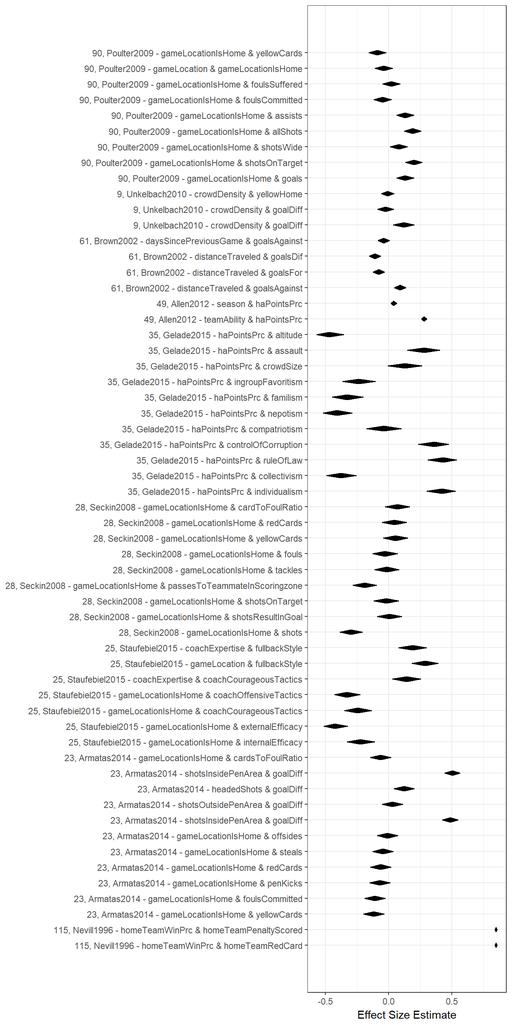

### Game location, before meta-analysis

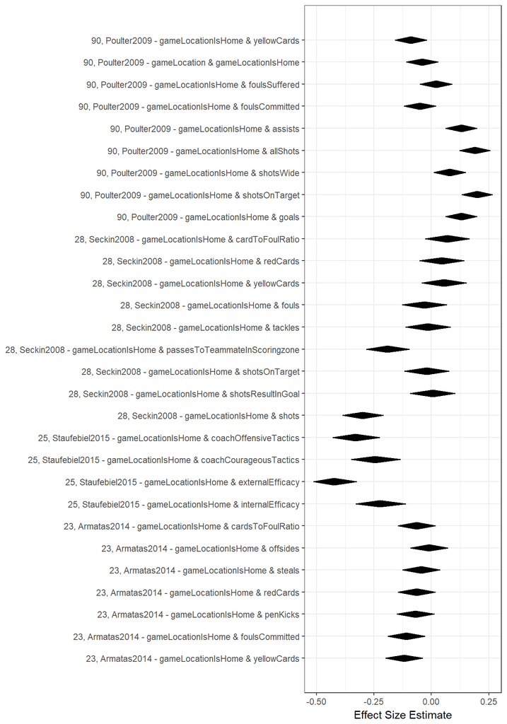

|  | study | lo | r | hi |
| --- | --- | --- | --- | --- |
| 26 | 23, Armatas2014 | -0.1987684 | -0.1191452 | -0.0379595 |
| 27 | 23, Armatas2014 | -0.1892079 | -0.1093405 | -0.0280359 |
| 28 | 23, Armatas2014 | -0.1505265 | -0.0698291 | 0.0117926 |
| 29 | 23, Armatas2014 | -0.1456473 | -0.0648631 | 0.0167803 |
| 30 | 23, Armatas2014 | -0.1260470 | -0.0449545 | 0.0367348 |
| 31 | 23, Armatas2014 | -0.0914795 | -0.0099995 | 0.0716135 |
| 36 | 23, Armatas2014 | -0.1456473 | -0.0648631 | 0.0167803 |
| 38 | 25, Staufebiel2015 | -0.3290450 | -0.2236068 | -0.1126618 |
| 39 | 25, Staufebiel2015 | -0.5132912 | -0.4242641 | -0.3262031 |
| 40 | 25, Staufebiel2015 | -0.3490308 | -0.2449490 | -0.1348975 |
| 41 | 25, Staufebiel2015 | -0.4292709 | -0.3316625 | -0.2263961 |
| 46 | 28, Seckin2008 | -0.3862644 | -0.3004466 | -0.2094720 |
| 47 | 28, Seckin2008 | -0.0921294 | 0.0049999 | 0.1020350 |
| 48 | 28, Seckin2008 | -0.1168538 | -0.0199960 | 0.0772386 |
| 49 | 28, Seckin2008 | -0.2832171 | -0.1913951 | -0.0960960 |
| 50 | 28, Seckin2008 | -0.1119200 | -0.0149983 | 0.0822060 |
| 51 | 28, Seckin2008 | -0.1267023 | -0.0299865 | 0.0672940 |
| 52 | 28, Seckin2008 | -0.0423937 | 0.0549170 | 0.1511955 |
| 53 | 28, Seckin2008 | -0.0523586 | 0.0449545 | 0.1414219 |
| 54 | 28, Seckin2008 | -0.0274415 | 0.0698291 | 0.1657898 |
| 88 | 90, Poulter2009 | 0.0612376 | 0.1300000 | 0.1975342 |
| 89 | 90, Poulter2009 | 0.1325230 | 0.2000000 | 0.2656318 |
| 90 | 90, Poulter2009 | 0.0107454 | 0.0800000 | 0.1484908 |
| 91 | 90, Poulter2009 | 0.1222964 | 0.1900000 | 0.2559435 |
| 92 | 90, Poulter2009 | 0.0612376 | 0.1300000 | 0.1975342 |
| 93 | 90, Poulter2009 | -0.1189021 | -0.0500000 | 0.0193813 |
| 94 | 90, Poulter2009 | -0.0493826 | 0.0200000 | 0.0891905 |
| 95 | 90, Poulter2009 | -0.1090119 | -0.0400000 | 0.0293957 |
| 96 | 90, Poulter2009 | -0.1583265 | -0.0900000 | -0.0208157 |

### Home advantage, before meta-analysis

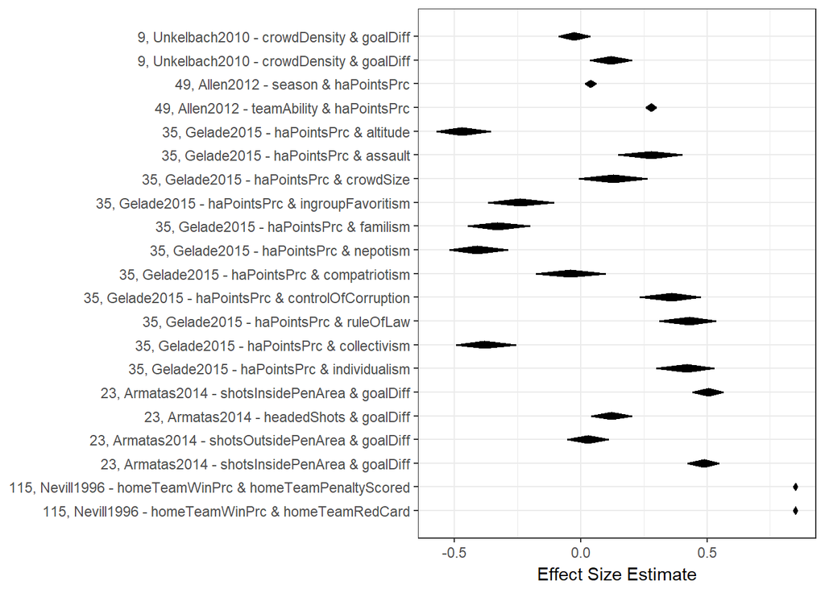

|  | study | lo | r | hi |
| --- | --- | --- | --- | --- |
| 12 | 115, Nevill1996 | 0.8402349 | 0.850 | 0.8592139 |
| 13 | 115, Nevill1996 | 0.8402349 | 0.850 | 0.8592139 |
| 32 | 23, Armatas2014 | 0.4232918 | 0.488 | 0.5477547 |
| 33 | 23, Armatas2014 | -0.0516811 | 0.030 | 0.1112823 |
| 34 | 23, Armatas2014 | 0.0418653 | 0.123 | 0.2025231 |
| 35 | 23, Armatas2014 | 0.4427147 | 0.506 | 0.5642691 |
| 56 | 35, Gelade2015 | 0.2999338 | 0.420 | 0.5269673 |
| 57 | 35, Gelade2015 | -0.4917037 | -0.380 | -0.2559919 |
| 58 | 35, Gelade2015 | 0.3109994 | 0.430 | 0.5357261 |
| 59 | 35, Gelade2015 | 0.2342114 | 0.360 | 0.4739335 |
| 60 | 35, Gelade2015 | -0.1764019 | -0.040 | 0.0979092 |
| 61 | 35, Gelade2015 | -0.5181858 | -0.410 | -0.2889003 |
| 62 | 35, Gelade2015 | -0.4471029 | -0.330 | -0.2017758 |
| 63 | 35, Gelade2015 | -0.3653267 | -0.240 | -0.1061278 |
| 64 | 35, Gelade2015 | -0.0075052 | 0.130 | 0.2626802 |
| 65 | 35, Gelade2015 | 0.1483343 | 0.280 | 0.4019121 |
| 66 | 35, Gelade2015 | -0.5705349 | -0.470 | -0.3555871 |
| 68 | 49, Allen2012 | 0.2593121 | 0.280 | 0.3004310 |
| 69 | 49, Allen2012 | 0.0177083 | 0.040 | 0.0622520 |
| 77 | 9, Unkelbach2010 | 0.0362218 | 0.120 | 0.2021033 |
| 78 | 9, Unkelbach2010 | -0.0872641 | -0.025 | 0.0374586 |

### Meta-analysis of game location effect sizes

#### Main results

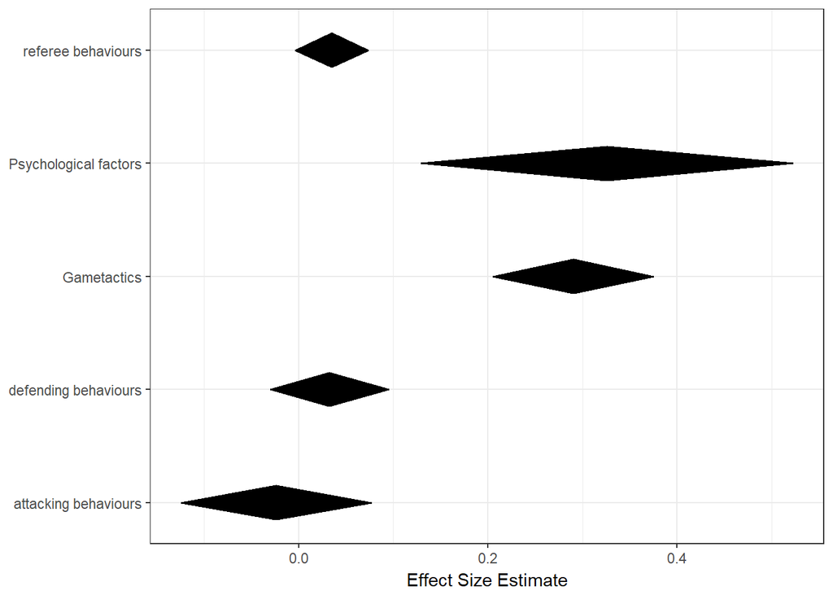

|  | vars | lo | r | hi |
| --- | --- | --- | --- | --- |
| attacking behaviours | attacking behaviours | -0.1243059 | -0.0235799 | 0.0771461 |
| defending behaviours | defending behaviours | -0.0298112 | 0.0325902 | 0.0949916 |
| Gametactics | Gametactics | 0.2051823 | 0.2900882 | 0.3749940 |
| Psychological factors | Psychological factors | 0.1292686 | 0.3258725 | 0.5224763 |
| referee behaviours | referee behaviours | -0.0037864 | 0.0348133 | 0.0734130 |

#### Detailed meta-analysis

##### attacking behaviours

```
Random-Effects Model (k = 10; tau^2 estimator: REML)

tau^2 (estimated amount of total heterogeneity): 0.0247 (SE = 0.0124)
tau (square root of estimated tau^2 value):      0.1573
I^2 (total heterogeneity / total variability):   94.10%
H^2 (total variability / sampling variability):  16.95

Test for Heterogeneity:
Q(df = 9) = 138.1767, p-val < .0001

Model Results:

estimate      se     zval    pval    ci.lb   ci.ub
 -0.0236  0.0514  -0.4588  0.6464  -0.1243  0.0771

---
Signif. codes:  0 '***' 0.001 '**' 0.01 '*' 0.05 '.' 0.1 ' ' 1
```

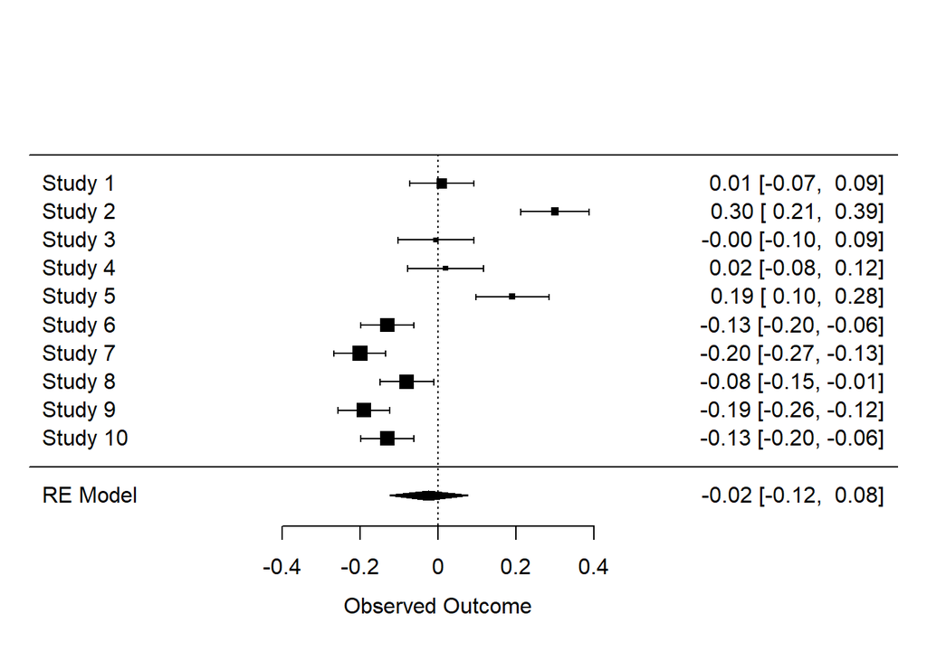

##### defending behaviours

```
Random-Effects Model (k = 2; tau^2 estimator: REML)

tau^2 (estimated amount of total heterogeneity): 0 (SE = 0.0030)
tau (square root of estimated tau^2 value):      0
I^2 (total heterogeneity / total variability):   0.00%
H^2 (total variability / sampling variability):  1.00

Test for Heterogeneity:
Q(df = 1) = 0.2146, p-val = 0.6432

Model Results:

estimate      se    zval    pval    ci.lb   ci.ub
  0.0326  0.0318  1.0236  0.3060  -0.0298  0.0950

---
Signif. codes:  0 '***' 0.001 '**' 0.01 '*' 0.05 '.' 0.1 ' ' 1
```

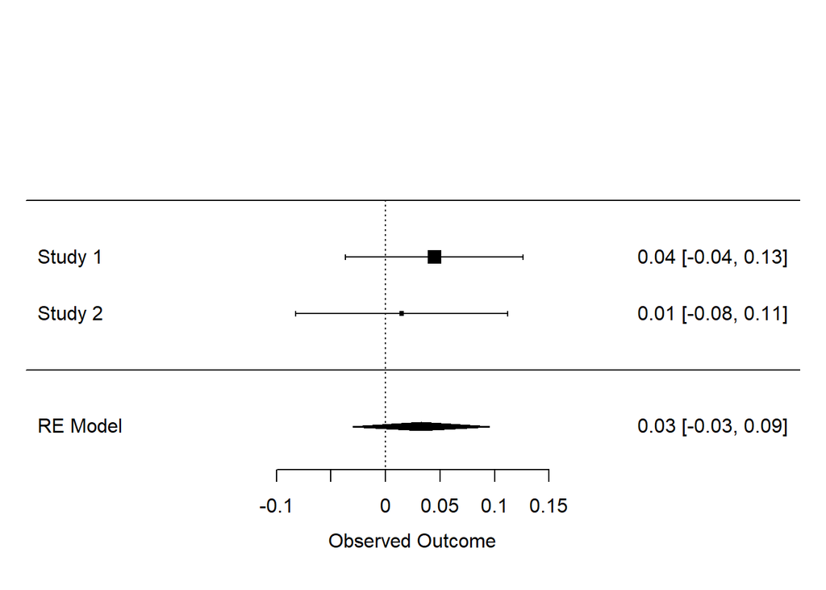

##### Gametactics

```
Random-Effects Model (k = 2; tau^2 estimator: REML)

tau^2 (estimated amount of total heterogeneity): 0.0009 (SE = 0.0053)
tau (square root of estimated tau^2 value):      0.0305
I^2 (total heterogeneity / total variability):   24.71%
H^2 (total variability / sampling variability):  1.33

Test for Heterogeneity:
Q(df = 1) = 1.3282, p-val = 0.2491

Model Results:

estimate      se    zval    pval   ci.lb   ci.ub
  0.2901  0.0433  6.6964  <.0001  0.2052  0.3750  ***

---
Signif. codes:  0 '***' 0.001 '**' 0.01 '*' 0.05 '.' 0.1 ' ' 1
```

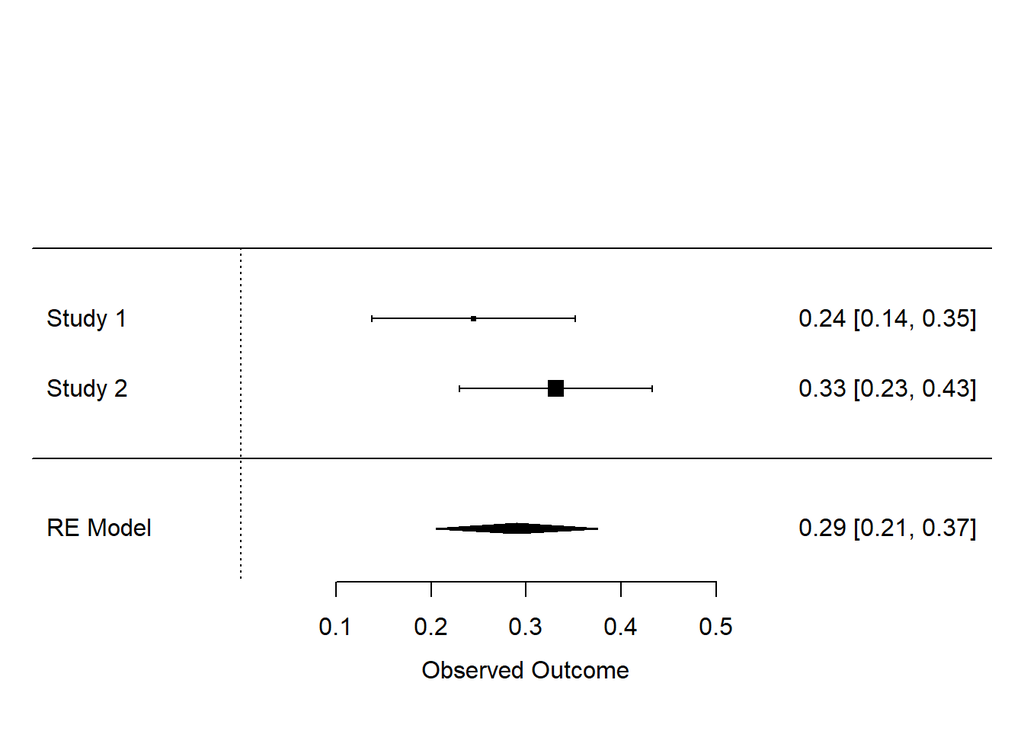

##### Psychological factors

```
Random-Effects Model (k = 2; tau^2 estimator: REML)

tau^2 (estimated amount of total heterogeneity): 0.0175 (SE = 0.0285)
tau (square root of estimated tau^2 value):      0.1322
I^2 (total heterogeneity / total variability):   86.79%
H^2 (total variability / sampling variability):  7.57

Test for Heterogeneity:
Q(df = 1) = 7.5674, p-val = 0.0059

Model Results:

estimate      se    zval    pval   ci.lb   ci.ub
  0.3259  0.1003  3.2487  0.0012  0.1293  0.5225  **

---
Signif. codes:  0 '***' 0.001 '**' 0.01 '*' 0.05 '.' 0.1 ' ' 1
```

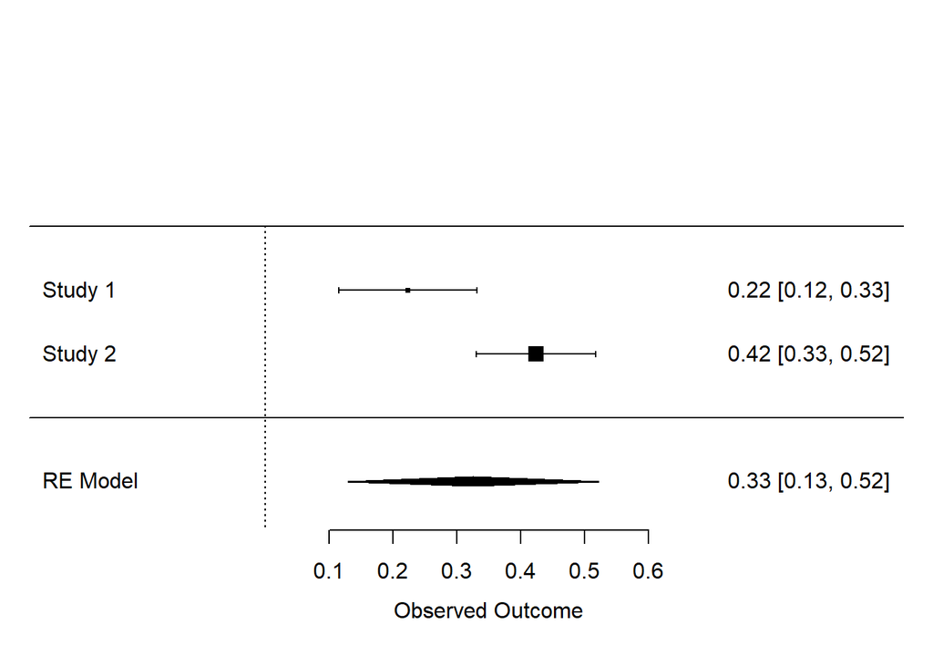

##### referee behaviours

```
Random-Effects Model (k = 11; tau^2 estimator: REML)

tau^2 (estimated amount of total heterogeneity): 0.0025 (SE = 0.0019)
tau (square root of estimated tau^2 value):      0.0497
I^2 (total heterogeneity / total variability):   58.83%
H^2 (total variability / sampling variability):  2.43

Test for Heterogeneity:
Q(df = 10) = 23.9022, p-val = 0.0079

Model Results:

estimate      se    zval    pval    ci.lb   ci.ub
  0.0348  0.0197  1.7677  0.0771  -0.0038  0.0734  .

---
Signif. codes:  0 '***' 0.001 '**' 0.01 '*' 0.05 '.' 0.1 ' ' 1
```

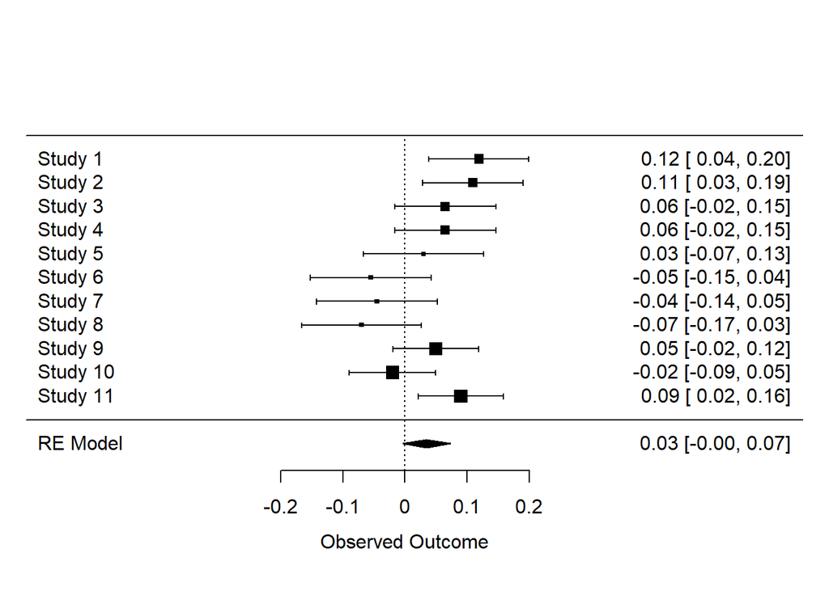

##### uncategorized

```
Random-Effects Model (k = 2; tau^2 estimator: REML)

tau^2 (estimated amount of total heterogeneity): 0.0045 (SE = 0.0085)
tau (square root of estimated tau^2 value):      0.0674
I^2 (total heterogeneity / total variability):   75.43%
H^2 (total variability / sampling variability):  4.07

Test for Heterogeneity:
Q(df = 1) = 4.0699, p-val = 0.0437

Model Results:

estimate      se    zval    pval    ci.lb   ci.ub
  0.0128  0.0549  0.2329  0.8158  -0.0948  0.1203

---
Signif. codes:  0 '***' 0.001 '**' 0.01 '*' 0.05 '.' 0.1 ' ' 1
```

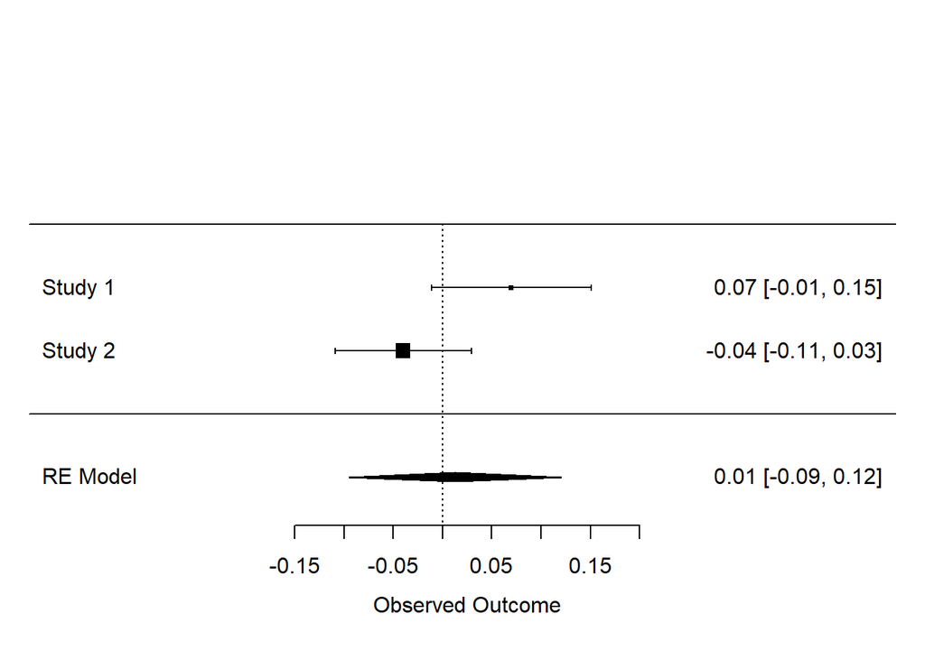

### Meta-analysis of home advantage effect sizes

#### Main results

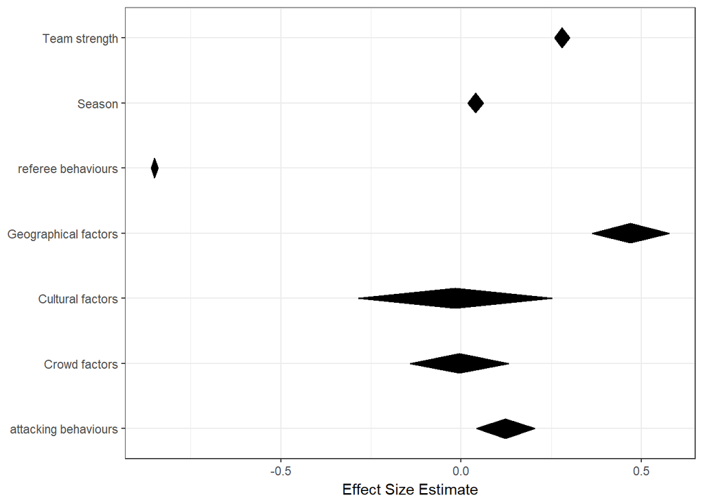

|  | vars | lo | r | hi |
| --- | --- | --- | --- | --- |
| attacking behaviours | attacking behaviours | 0.0426401 | 0.1230000 | 0.2033599 |
| Crowd factors | Crowd factors | -0.1411014 | -0.0047431 | 0.1316151 |
| Cultural factors | Cultural factors | -0.2845751 | -0.0164739 | 0.2516272 |
| Geographical factors | Geographical factors | 0.3628251 | 0.4700000 | 0.5771749 |
| referee behaviours | referee behaviours | -0.8594823 | -0.8500000 | -0.8405177 |
| Season | Season | 0.0177273 | 0.0400000 | 0.0622727 |
| Team strength | Team strength | 0.2594406 | 0.2800000 | 0.3005594 |

#### Detailed meta-analysis

##### attacking behaviours

```
Fixed-Effects Model (k = 1)

Test for Heterogeneity:
Q(df = 0) = 0.0000, p-val = 1.0000

Model Results:

estimate      se    zval    pval   ci.lb   ci.ub
  0.1230  0.0410  2.9999  0.0027  0.0426  0.2034  **

---
Signif. codes:  0 '***' 0.001 '**' 0.01 '*' 0.05 '.' 0.1 ' ' 1
```

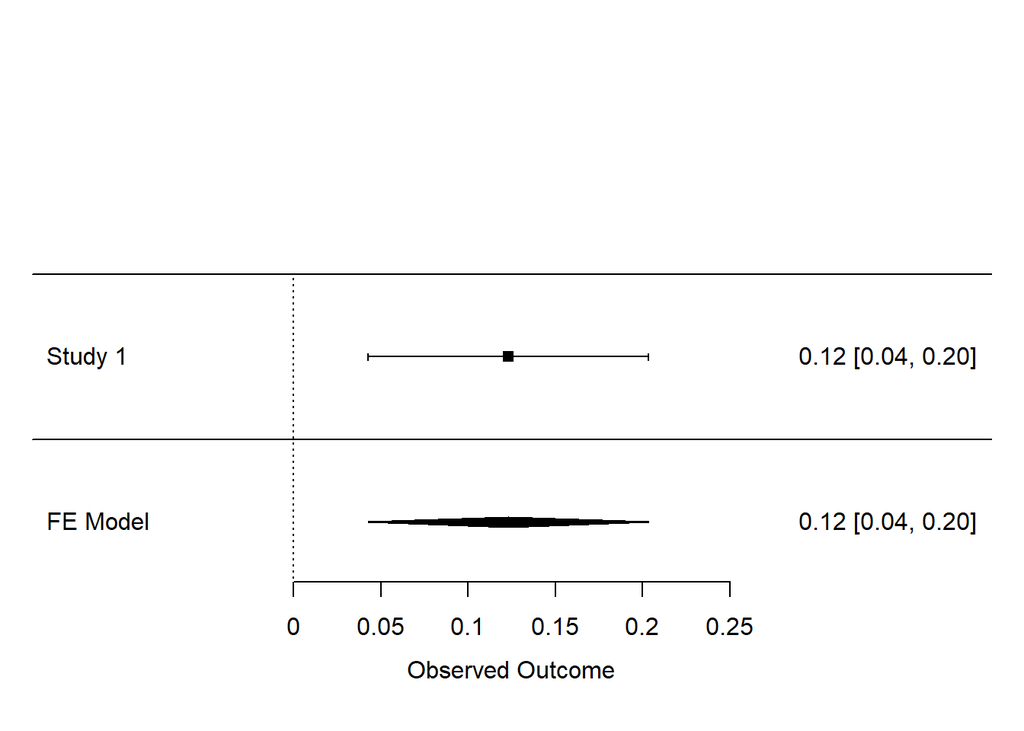

##### Crowd factors

```
Random-Effects Model (k = 3; tau^2 estimator: REML)

tau^2 (estimated amount of total heterogeneity): 0.0122 (SE = 0.0146)
tau (square root of estimated tau^2 value):      0.1103
I^2 (total heterogeneity / total variability):   85.85%
H^2 (total variability / sampling variability):  7.07

Test for Heterogeneity:
Q(df = 2) = 12.0736, p-val = 0.0024

Model Results:

estimate      se     zval    pval    ci.lb   ci.ub
 -0.0047  0.0696  -0.0682  0.9456  -0.1411  0.1316

---
Signif. codes:  0 '***' 0.001 '**' 0.01 '*' 0.05 '.' 0.1 ' ' 1
```

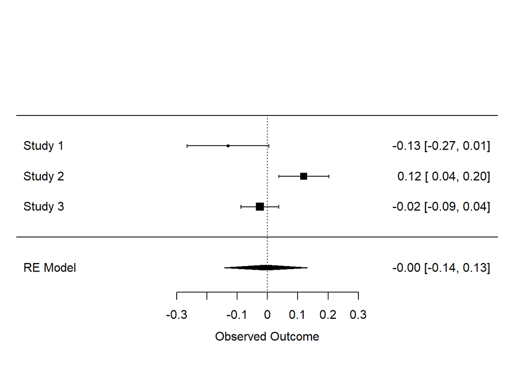

##### Cultural factors

```
Random-Effects Model (k = 8; tau^2 estimator: REML)

tau^2 (estimated amount of total heterogeneity): 0.1460 (SE = 0.0800)
tau (square root of estimated tau^2 value):      0.3820
I^2 (total heterogeneity / total variability):   97.53%
H^2 (total variability / sampling variability):  40.48

Test for Heterogeneity:
Q(df = 7) = 291.6813, p-val < .0001

Model Results:

estimate      se     zval    pval    ci.lb   ci.ub
 -0.0165  0.1368  -0.1204  0.9041  -0.2846  0.2516

---
Signif. codes:  0 '***' 0.001 '**' 0.01 '*' 0.05 '.' 0.1 ' ' 1
```

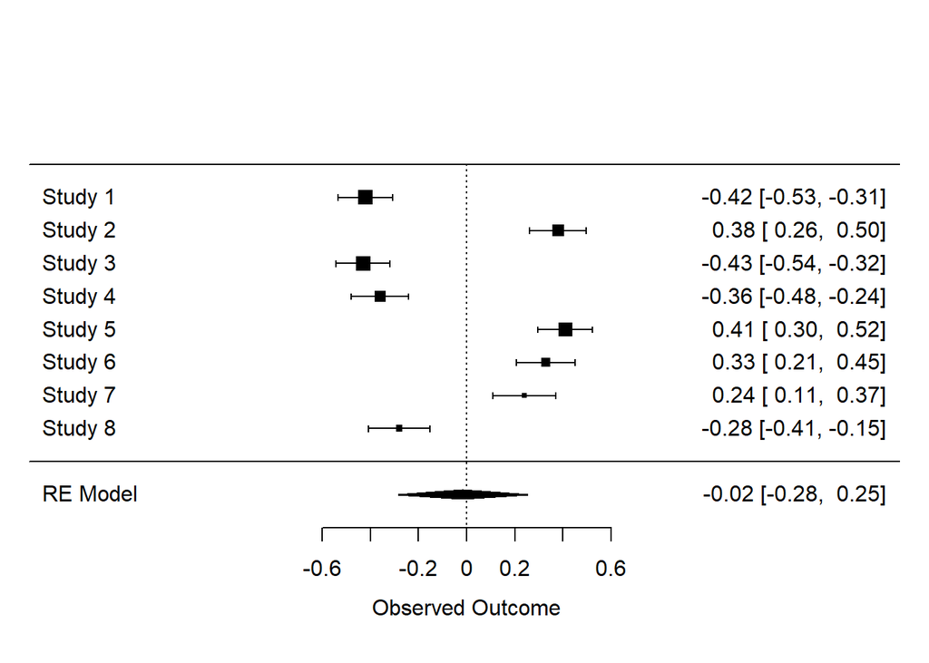

##### Geographical factors

```
Fixed-Effects Model (k = 1)

Test for Heterogeneity:
Q(df = 0) = 0.0000, p-val = 1.0000

Model Results:

estimate      se    zval    pval   ci.lb   ci.ub
  0.4700  0.0547  8.5951  <.0001  0.3628  0.5772  ***

---
Signif. codes:  0 '***' 0.001 '**' 0.01 '*' 0.05 '.' 0.1 ' ' 1
```

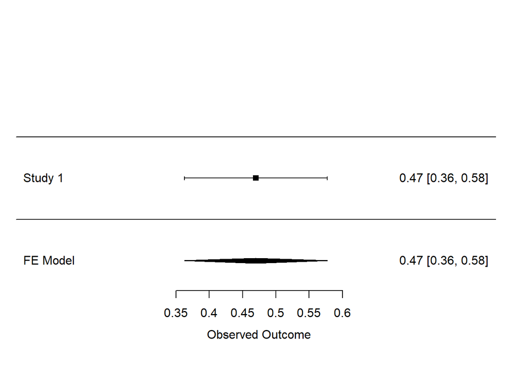

##### referee behaviours

```
Fixed-Effects Model (k = 1)

Test for Heterogeneity:
Q(df = 0) = 0.0000, p-val = 1.0000

Model Results:

estimate      se       zval    pval    ci.lb    ci.ub
 -0.8500  0.0048  -175.6928  <.0001  -0.8595  -0.8405  ***

---
Signif. codes:  0 '***' 0.001 '**' 0.01 '*' 0.05 '.' 0.1 ' ' 1
```

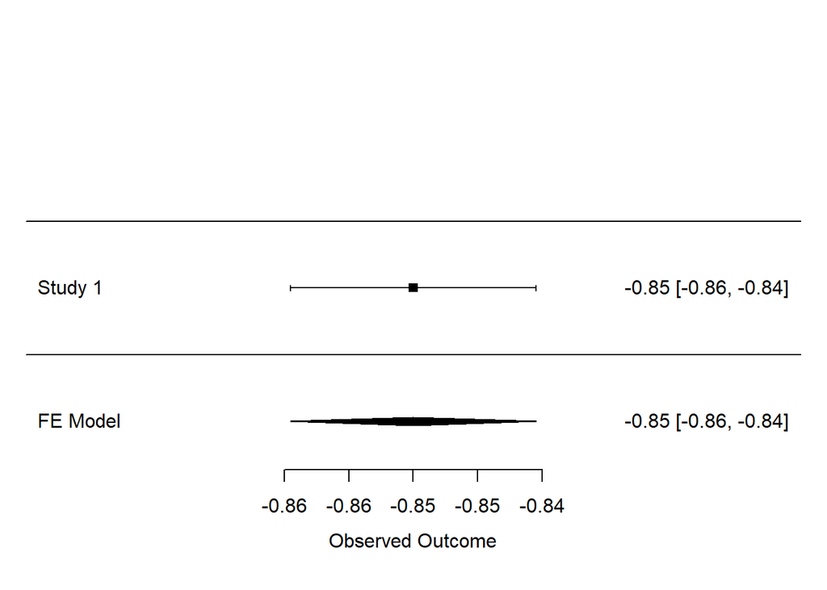

##### Season

```
Fixed-Effects Model (k = 1)

Test for Heterogeneity:
Q(df = 0) = 0.0000, p-val = 1.0000

Model Results:

estimate      se    zval    pval   ci.lb   ci.ub
  0.0400  0.0114  3.5199  0.0004  0.0177  0.0623  ***

---
Signif. codes:  0 '***' 0.001 '**' 0.01 '*' 0.05 '.' 0.1 ' ' 1
```

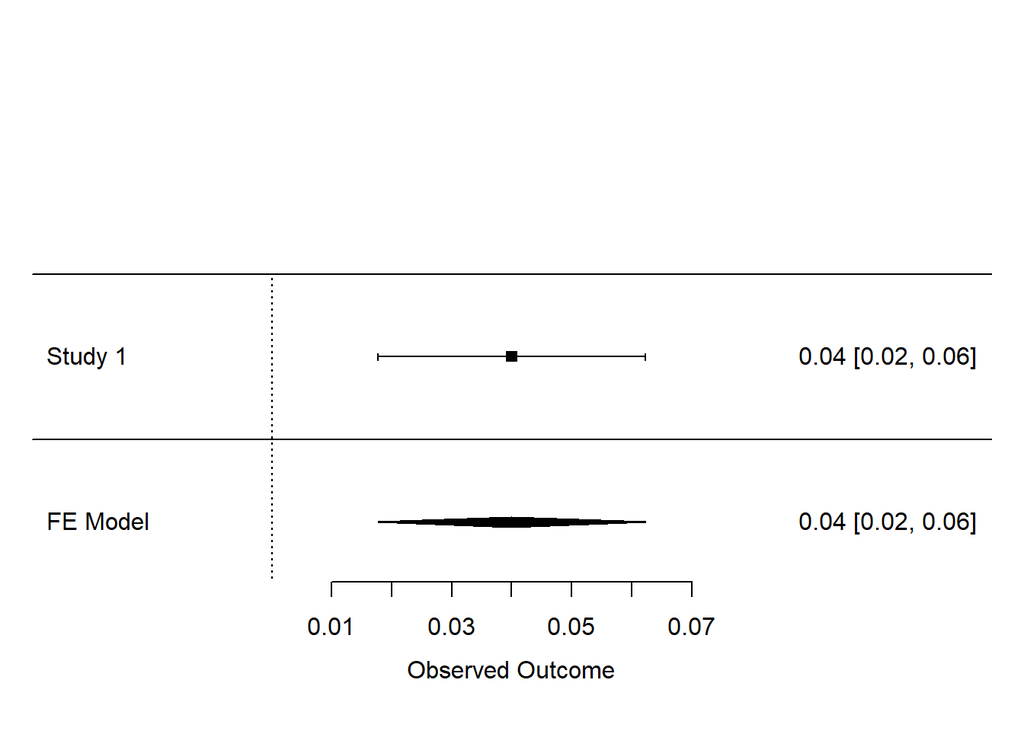

##### Team strength

```
Fixed-Effects Model (k = 1)

Test for Heterogeneity:
Q(df = 0) = 0.0000, p-val = 1.0000

Model Results:

estimate      se     zval    pval   ci.lb   ci.ub
  0.2800  0.0105  26.6929  <.0001  0.2594  0.3006  ***

---
Signif. codes:  0 '***' 0.001 '**' 0.01 '*' 0.05 '.' 0.1 ' ' 1
```

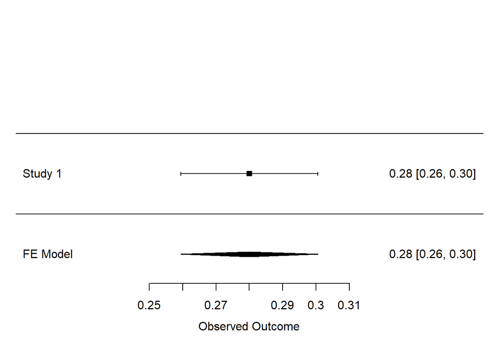

##### uncategorized

```
Random-Effects Model (k = 5; tau^2 estimator: REML)

tau^2 (estimated amount of total heterogeneity): 0.3035 (SE = 0.2158)
tau (square root of estimated tau^2 value):      0.5509
I^2 (total heterogeneity / total variability):   99.76%
H^2 (total variability / sampling variability):  411.38

Test for Heterogeneity:
Q(df = 4) = 4046.6119, p-val < .0001

Model Results:

estimate      se    zval    pval    ci.lb   ci.ub
  0.0422  0.2471  0.1710  0.8642  -0.4420  0.5265

---
Signif. codes:  0 '***' 0.001 '**' 0.01 '*' 0.05 '.' 0.1 ' ' 1
```

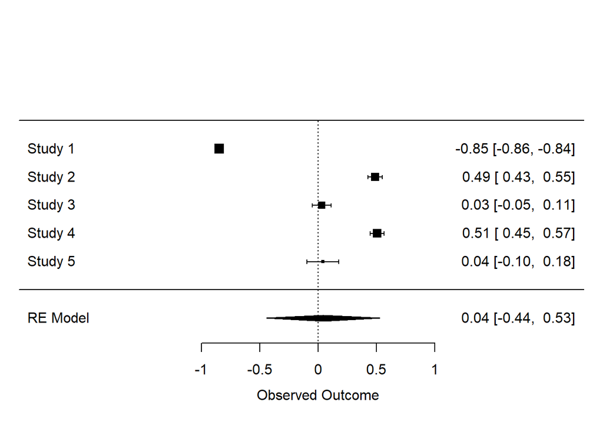